# Anthropogenic N deposition alters microbial communities on decaying fine roots and soil organic matter biochemistry

William A. Argiroff

February 4, 2019

# I. About

This document contains all analyses that accompany the manuscript, “*Anthropogenic N deposition alters microbial communities on decaying fine roots and soil organic matter biochemistry*,” by W. A. Argiroff, D. R. Zak, R. A. Upchurch, S. O. Salley, and A. S. Grandy.

All package and version information used in the analyses for this study is described below. For analyses not run using `R`, the files containing corresponding code are listed and described in this document.

# II. Soil organic matter biochemistry

## A. Summary and ANOVA

```r
# Calculate totals by source, undecomposed roots
pyr.gcms.rootp.source.tbl <- dplyr::as_tibble(data.table::fread("pyr.gcms.data.txt", sep = "\t", header = TRUE)) %>%
  # Rename columns
  dplyr::rename(COMPOUND_ID = Compound_ID,
                COMPOUND = Compound,
                TYPE = Type,
                SOURCE = Source) %>%
  # Convert to long format
  tidyr::gather(SAMPLE.NAME, PROPORTION, -c(COMPOUND_ID, COMPOUND, TYPE, SOURCE)) %>%
  # Add sample information
  dplyr::inner_join(as_tibble(fread("pyr.gc.sample.info.txt", sep = "\t", header = TRUE)), ., by = "SAMPLE.NAME") %>%
  # Calculate percentages
  dplyr::mutate(PERCENTAGE = 100 * PROPORTION) %>%
  # Fix source names
  dplyr::mutate(SOURCE = ifelse(SOURCE == "Lignin+TMAH", "Lignin", SOURCE),
                SOURCE = ifelse(SOURCE == "Phenol+TMAH", "Phenol", SOURCE),
                SOURCE = ifelse(SOURCE == "Unknown Origin", "Unknown", SOURCE)) %>%
  # Group table
  dplyr::group_by(GROUP, SAMPLE.NAME, PLOT, SITE, TREATMENT, SUBSTRATE, SOURCE) %>%
  # Calculate totals
  dplyr::summarise(PERCENTAGE = sum(PERCENTAGE)) %>%
  # Ungroup
  dplyr::ungroup() %>%
  # Filter
  dplyr::filter(SUBSTRATE == "root.p") %>%
  # Wide format
  tidyr::spread(SOURCE, PERCENTAGE) %>%
  # Select relevant columns
  dplyr::select(-GROUP, -SAMPLE.NAME, -SUBSTRATE) %>%
  # Sort
  dplyr::arrange(PLOT)

# Calculate totals by source, decomposed roots
pyr.gcms.root.source.tbl <- dplyr::as_tibble(data.table::fread("pyr.gcms.data.txt", sep = "\t", header = TRUE)) %>%
  # Rename columns
  dplyr::rename(COMPOUND_ID = Compound_ID,
                COMPOUND = Compound,
                TYPE = Type,
                SOURCE = Source) %>%
  # Convert to long format
  tidyr::gather(SAMPLE.NAME, PROPORTION, -c(COMPOUND_ID, COMPOUND, TYPE, SOURCE)) %>%
  # Add sample information
  dplyr::inner_join(as_tibble(fread("pyr.gc.sample.info.txt", sep = "\t", header = TRUE)), ., by = "SAMPLE.NAME") %>%
  # Calculate percentages
  dplyr::mutate(PERCENTAGE = 100 * PROPORTION) %>%
  # Fix source names
  dplyr::mutate(SOURCE = ifelse(SOURCE == "Lignin+TMAH", "Lignin", SOURCE),
                SOURCE = ifelse(SOURCE == "Phenol+TMAH", "Phenol", SOURCE),
                SOURCE = ifelse(SOURCE == "Unknown Origin", "Unknown", SOURCE)) %>%
  # Group table
  dplyr::group_by(GROUP, SAMPLE.NAME, PLOT, SITE, TREATMENT, SUBSTRATE, SOURCE) %>%
  # Calculate totals
  dplyr::summarise(PERCENTAGE = sum(PERCENTAGE)) %>%
  # Ungroup
  dplyr::ungroup() %>%
  # Filter
  dplyr::filter(SUBSTRATE == "root") %>%
  # Wide format
  tidyr::spread(SOURCE, PERCENTAGE) %>%
  # Select relevant columns
  dplyr::select(-GROUP, -SAMPLE.NAME, -SUBSTRATE) %>%
  # Sort
  dplyr::arrange(PLOT)

# Calculate totals by source, SOM
pyr.gcms.som.source.tbl <- dplyr::as_tibble(data.table::fread("pyr.gcms.data.txt", sep = "\t", header = TRUE)) %>%
  # Rename columns
  dplyr::rename(COMPOUND_ID = Compound_ID,
                COMPOUND = Compound,
                TYPE = Type,
                SOURCE = Source) %>%
  # Convert to long format
  tidyr::gather(SAMPLE.NAME, PROPORTION, -c(COMPOUND_ID, COMPOUND, TYPE, SOURCE)) %>%
  # Add sample information
  dplyr::inner_join(as_tibble(fread("pyr.gc.sample.info.txt", sep = "\t", header = TRUE)), ., by = "SAMPLE.NAME") %>%
  # Calculate percentages
  dplyr::mutate(PERCENTAGE = 100 * PROPORTION) %>%
  # Fix source names
  dplyr::mutate(SOURCE = ifelse(SOURCE == "Lignin+TMAH", "Lignin", SOURCE),
                SOURCE = ifelse(SOURCE == "Phenol+TMAH", "Phenol", SOURCE),
                SOURCE = ifelse(SOURCE == "Unknown Origin", "Unknown", SOURCE)) %>%
  # Group table
  dplyr::group_by(GROUP, SAMPLE.NAME, PLOT, SITE, TREATMENT, SUBSTRATE, SOURCE) %>%
  # Calculate totals
  dplyr::summarise(PERCENTAGE = sum(PERCENTAGE)) %>%
  # Ungroup
  dplyr::ungroup() %>%
  # Filter
  dplyr::filter(SUBSTRATE == "mineral.soil") %>%
  # Wide format
  tidyr::spread(SOURCE, PERCENTAGE) %>%
  # Select relevant columns
  dplyr::select(-GROUP, -SAMPLE.NAME, -SUBSTRATE) %>%
  # Sort
  dplyr::arrange(PLOT)

# Convert to data frame
pyr.gcms.som.source.df <- as.data.frame(pyr.gcms.som.source.tbl, stringsAsFactors = FALSE)
# Add row names
row.names(pyr.gcms.som.source.df) <- pyr.gcms.som.source.df$PLOT
# ANOVA on log2 transformed percentages
pyr.gcms.som.source.aov <- manova(log2(cbind(as.matrix(pyr.gcms.som.source.df[4 : ncol(pyr.gcms.som.source.df)]))) ~ SITE * TREATMENT, data = pyr.gcms.som.source.df)
# Get summary
pyr.gcms.som.source.aov.summary <- summary.aov(pyr.gcms.som.source.aov)

# Fisher's lsd, SOM N-bearing
pyr.gcms.som.nbear.lsd <- LSD.test(aov(log2(cbind(as.matrix(pyr.gcms.som.source.df[7]))) ~ SITE * TREATMENT, data = pyr.gcms.som.source.df), c("SITE", "TREATMENT"), alpha = 0.1, p.adj = "none")

# Fisher's lsd, SOM polysaccharide
pyr.gcms.som.poly.lsd <- LSD.test(aov(log2(cbind(as.matrix(pyr.gcms.som.source.df[9]))) ~ SITE * TREATMENT, data = pyr.gcms.som.source.df), c("SITE", "TREATMENT"), alpha = 0.1, p.adj = "none")

# Convert to data frame
pyr.gcms.rootp.source.df <- as.data.frame(pyr.gcms.rootp.source.tbl)
# Add row names
row.names(pyr.gcms.rootp.source.df) <- pyr.gcms.rootp.source.df$PLOT
# ANOVA
pyr.gcms.rootp.source.aov <- manova(as.matrix(pyr.gcms.rootp.source.df[4 : ncol(pyr.gcms.rootp.source.df)]) ~ SITE * TREATMENT, data = pyr.gcms.rootp.source.df)
# Get summary
pyr.gcms.rootp.source.aov.summary <- summary.aov(pyr.gcms.rootp.source.aov)

# Convert to data frame
pyr.gcms.root.source.df <- as.data.frame(pyr.gcms.root.source.tbl)
# Add row names
row.names(pyr.gcms.root.source.df) <- pyr.gcms.root.source.df$PLOT
# ANOVA
pyr.gcms.root.source.aov <- manova(as.matrix(pyr.gcms.root.source.df[4 : ncol(pyr.gcms.root.source.df)]) ~ SITE * TREATMENT, data = pyr.gcms.rootp.source.df)
# Get summary
pyr.gcms.root.source.aov.summary <- summary.aov(pyr.gcms.root.source.aov)
```

## B. Create **Figure 1**

```r
# Write facet label function
facet_label <- function(x) {
  # If pre-incubated root
  if (x == "root.p") {
    # Assign Undecomposed root litter
    tmp1 <- "Un-decayed root litter"
    # If incubated root
  } else if (x == "root") {
    # Assign Root litter at 12 months
    tmp1 <- "Decaying root litter"
    # If SOM
  } else {
    # Assign soil organic matter
    tmp1 <- "Soil organic matter"
  }

  # Return result
  return(tmp1)
}

# Funcion for standard error
se <- function(x) {
  sd(x) / sqrt(length(x))
}

# Calculate means and SE by source
pyr.gcms.source.tbl <- dplyr::as_tibble(data.table::fread("pyr.gcms.data.txt", sep = "\t", header = TRUE)) %>%
  # Rename columns
  dplyr::rename(COMPOUND_ID = Compound_ID,
                COMPOUND = Compound,
                TYPE = Type,
                SOURCE = Source) %>%
  # Convert to long format
  tidyr::gather(SAMPLE.NAME, PROPORTION, -c(COMPOUND_ID, COMPOUND, TYPE, SOURCE)) %>%
  # Add sample information
  dplyr::inner_join(as_tibble(fread("pyr.gc.sample.info.txt", sep = "\t", header = TRUE)), ., by = "SAMPLE.NAME") %>%
  # Calculate percentages
  dplyr::mutate(PERCENTAGE = 100 * PROPORTION) %>%
  # Fix source names
  dplyr::mutate(SOURCE = ifelse(SOURCE == "Lignin+TMAH", "Lignin", SOURCE),
                SOURCE = ifelse(SOURCE == "Phenol+TMAH", "Phenol", SOURCE),
                SOURCE = ifelse(SOURCE == "Unknown Origin", "Unknown", SOURCE)) %>%
  # Group table
  dplyr::group_by(GROUP, SAMPLE.NAME, PLOT, SITE, TREATMENT, SUBSTRATE, SOURCE) %>%
  # Calculate totals
  dplyr::summarise(PERCENTAGE = sum(PERCENTAGE)) %>%
  # Ungroup
  dplyr::ungroup() %>%
  # Group by treatment
  dplyr::group_by(SOURCE, SUBSTRATE, TREATMENT) %>%
  # Calculate mean and SE
  dplyr::summarise(MEAN.PERCENTAGE = mean(PERCENTAGE),
                   SE.PERCENTAGE = se(PERCENTAGE)) %>%
  # Ungroup
  dplyr::ungroup() %>%
  # Calculate error bar maximums and minimums
  dplyr::mutate(ERROR.BAR.MAX = MEAN.PERCENTAGE + SE.PERCENTAGE,
                ERROR.BAR.MIN = MEAN.PERCENTAGE - SE.PERCENTAGE) %>%
  # Add bottom error bar color and facet labels
  dplyr::mutate(ERROR.BAR.COLOR = ifelse(TREATMENT == "Amb", "black", "white"),
                FACET.LABEL = rep(NA, nrow(.)),
                FACET.LABEL = sapply(SUBSTRATE, facet_label)) %>%
  # Create factor for facet labels
  dplyr::mutate(FACET.LABEL = factor(FACET.LABEL, levels = c("Un-decayed root litter", "Decaying root litter", "Soil organic matter"))) %>%
  # Add significance label
  dplyr::mutate(SIG.LABEL = ifelse(SUBSTRATE == "mineral.soil" & SOURCE == "Lignin" & TREATMENT == "Ndep", "*", ""))

# Source biochemistry figure
pyr.gcms.source.fig <- ggplot(pyr.gcms.source.tbl, aes(x = SOURCE, y = MEAN.PERCENTAGE, fill = TREATMENT)) +
  # Specify boxplot
  geom_bar(stat = "identity",
           colour = "black",
           position = position_dodge(0.9)) +
  scale_y_continuous(expand = c(0, 0),
                     limits = c(0, 50),
                     breaks = c(0, 10, 20, 30, 40, 50),
                     labels = c("0%", "10%", "20%", "30%", "40%", "50%")) +
  # Update labels on treatment/time legend
  scale_fill_manual(values = c("white", "black"),
                    labels = c("  Ambient N", "  Experimental N")) +
  guides(title = NULL) +
  # Add x axis label
  labs(title = NULL,
       x = NULL,
       # Add y axis label
       y = "Biochemical composition\n ") +
  # Format plot
  theme(legend.title = element_blank(),
        # Remove panel and legend backgrounds
        panel.grid.major = element_blank(),
        panel.grid.minor = element_blank(),
        panel.background = element_blank(),
        legend.key = element_blank(),
        # Add axis lines
        axis.line.x = element_line(colour = "black", size = 0.6),
        axis.line.y = element_line(colour = "black", size = 0.6),
        # Format text
        axis.title.y = element_text(colour = "black", size = 16, face = "bold"),
        axis.text.x = element_text(colour = "black", size = 10, face = "bold", angle = 30, hjust = 1),
        axis.ticks.x = element_blank(),
        axis.ticks.y = element_line(colour = "black", size = 0.6),
        axis.text.y = element_text(colour = "black", size = 9, face = "bold"),
        legend.text = element_text(colour = "black", size = 9, face = "bold")) +
  # Wrap into facets by substrate
  facet_wrap(~ FACET.LABEL,
             scales = "free_x",
             ncol = 1) +
  geom_errorbar(aes(ymax = MEAN.PERCENTAGE, ymin = ERROR.BAR.MIN, colour = ERROR.BAR.COLOR),
                position = position_dodge(0.9),
                width = 0) +
  scale_color_identity() +
    geom_errorbar(aes(ymax = ERROR.BAR.MAX, ymin = MEAN.PERCENTAGE),
                  position = position_dodge(0.9),
                  width = 0,
                  colour = "black") +
  theme(legend.position = c(0.85, 0.95),
        strip.background = element_blank(),
        strip.text = element_text(colour = "black", size = 14, face = "bold")) +
  geom_text(data = pyr.gcms.source.tbl,
            aes(x = SOURCE, y = (pyr.gcms.source.tbl$ERROR.BAR.MAX + 5),
                label = SIG.LABEL),
            stat = "identity",
            size = 7)

# Save image
#ggsave("Figure_1.tiff", pyr.gcms.source.fig, device = "tiff", width = 7, height = 8.67, units = "in", dpi = 1200)
#ggsave("Figure_1.png", pyr.gcms.source.fig, device = "png", width = 7, height = 8.67, units = "in", dpi = 300)

# Calculate percent change
pyr.gcms.som.perc.change.tbl <- pyr.gcms.source.tbl %>%
  dplyr::filter(SUBSTRATE == "mineral.soil") %>%
  dplyr::select(SOURCE, SUBSTRATE, TREATMENT, MEAN.PERCENTAGE) %>%
  tidyr::spread(TREATMENT, MEAN.PERCENTAGE) %>%
  dplyr::mutate(PERC.CHANGE = 100 * ((Ndep - Amb) * (1 / Amb)))
```

**Figure 1** is shown below:

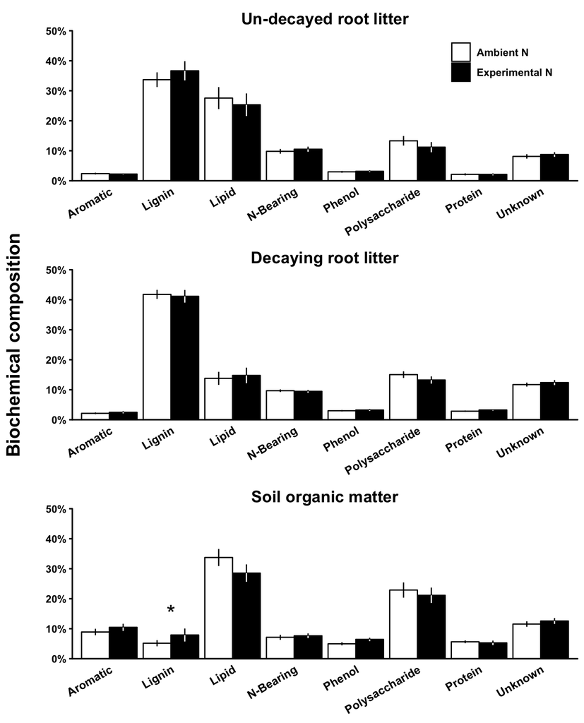

# III. Sequence quality control

## A. Bacteria

### 1. 16S sequence processing using `mothur`

Bacterial sequences were subjected to the quality control pipeline outlined in the file named `mothur.16s.batch`, and run in [mothur v1.40.5](https://www.mothur.org/). `.oligos` files matching barcoded primer sequences to corresponding samples are contained in the same folder, and named to correspond with appropriate `.fastq` files. Running the file `mothur.16s.batch` in mothur produces a `.shared` file (an OTU table) with OTUs clustered at 97% sequence similarity. This `.shared` file is used as input for all further analyses performed in `R`.

## B. Fungi

### 1. 28S sequence processing through unique sequences

The file named `mothur.28s.uniques.batch` can be run in `mothur` to produce unique quality sequences (in a file named `Gradient.28S.Roots.combined.trim.unique.fasta`. This output was then subset into 3 equally-sized files in order to assign taxonomy using the [RDP classifier (release 11, update 5)](https://rdp.cme.msu.edu/classifier/classifier.jsp), as described below.

### 2. Subset unique sequences `.fasta` file

```r
# Read in fungal unique sequences .fasta by uncommenting the following code
#f.unique.fasta <- read.fasta(file = "Gradient.28S.Roots.combined.trim.unique.fasta", seqtype = "DNA", as.string = FALSE, forceDNAtolower = FALSE, set.attributes = FALSE)

# Subset the file
#f.unique.1.fasta <- f.unique.fasta[1:40883]
# Subset the file
#f.unique.2.fasta <- f.unique.fasta[40884:81766]
# Subset the file
#f.unique.3.fasta <- f.unique.fasta[81767:122649]

# Get max sequence length
#f.unique.length <- max(sapply(f.unique.fasta, length))

# Write out subset file by uncommenting the following code
#write.fasta(sequences = f.unique.1.fasta, open = "w", names = names(f.unique.1.fasta), file.out = "Gradient.28S.Roots.combined.trim.unique.1.fasta", nbchar = f.unique.length, as.string = FALSE)
# Write out subset file
#write.fasta(sequences = f.unique.2.fasta, open = "w", names = names(f.unique.2.fasta), file.out = "Gradient.28S.Roots.combined.trim.unique.2.fasta", nbchar = f.unique.length, as.string = FALSE)
# Write out subset file
#write.fasta(sequences = f.unique.3.fasta, open = "w", names = names(f.unique.3.fasta), file.out = "Gradient.28S.Roots.combined.trim.unique.3.fasta", nbchar = f.unique.length, as.string = FALSE)
```

### 3. Classify unique 28S sequences

Sequences were uploaded to the [RDP classifier (release 11, update 5)](https://rdp.cme.msu.edu/classifier/classifier.jsp) and classified against the Fungal LSU Training Set 11. File headings from the output were then removed and files were concatenated into a single text file with taxonomic assignments, `Gradient.28S.Roots.combined.trim.unique.fasta_classified.txt`.

### 4. Format 28S initial taxonomy file

The concatenated RDP classification results were then formatted for `mothur` using the following code:

```r
# Write a function to re-format percentages for mothur
f_rdp_conf_format <- function(x) {
  # If the value contains a percentage
  if (grepl("%", x) == TRUE) {
    # Add ( to the front of it
    tmp1 <- paste("(", x, sep = "")
    # Add ); to the end by replacing %
    tmp2 <- gsub("\\%", ");", tmp1)
    # Otherwise
  } else {
    # Return the same value
    tmp2 <- x
  }
  # Return the value
  return(tmp2)
}

# Read in initial taxonomy table
f.tax.initial.tbl <- as_tibble(fread("Gradient.28S.Roots.combined.trim.unique.fasta_classified.txt", sep = "\t", header = FALSE)) %>%
  # Separate by ;
  tidyr::separate(V1, c("SEQ.ID", "EXTRA", "ROOT", "ROOT.CONF", "KINGDOM", "KINGDOM.CONF", "PHYLUM", "PHYLUM.CONF",
                        "CLASS", "CLASS.CONF", "ORDER", "ORDER.CONF", "FAMILY", "FAMILY.CONF", "GENUS", "GENUS.CONF"), sep = ";") %>%
  # Update root confidence
  dplyr::mutate(ROOT.CONF = sapply(ROOT.CONF, f_rdp_conf_format)) %>%
  # Update kingdom confidence
  dplyr::mutate(KINGDOM.CONF = sapply(KINGDOM.CONF, f_rdp_conf_format)) %>%
  # Update phylum confidence
  dplyr::mutate(PHYLUM.CONF = sapply(PHYLUM.CONF, f_rdp_conf_format)) %>%
  # Update class confidence
  dplyr::mutate(CLASS.CONF = sapply(CLASS.CONF, f_rdp_conf_format)) %>%
  # Update order confidence
  dplyr::mutate(ORDER.CONF = sapply(ORDER.CONF, f_rdp_conf_format)) %>%
  # Update family confidence
  dplyr::mutate(FAMILY.CONF = sapply(FAMILY.CONF, f_rdp_conf_format)) %>%
  # Update genus confidence
  dplyr::mutate(GENUS.CONF = sapply(GENUS.CONF, f_rdp_conf_format)) %>%
  # Remove the extra value
  dplyr::select(-EXTRA) %>%
  # Replace NA values with blank
  tidyr::replace_na(list(ROOT = "", ROOT.CONF = "", KINGDOM = "", KINGDOM.CONF = "",
                         PHYLUM = "", PHYLUM.CONF = "", CLASS = "", CLASS.CONF = "",
                         ORDER = "", ORDER.CONF = "", FAMILY = "", FAMILY.CONF = "",
                         GENUS = "", GENUS.CONF = "")) %>%
  # Combine into single entry
  tidyr::unite(TAXONOMY, ROOT, ROOT.CONF, KINGDOM, KINGDOM.CONF, PHYLUM, PHYLUM.CONF, CLASS, CLASS.CONF,
                         ORDER, ORDER.CONF, FAMILY, FAMILY.CONF, GENUS, GENUS.CONF, sep = "")

# Write out the result by uncommenting the following code
#write.table(f.tax.initial.tbl, file = "Gradient.28S.Roots.combined.trim.unique.fasta.classified.taxonomy", sep = "\t", col.names = FALSE, row.names = FALSE, quote = FALSE)
```

### 5. Process sequences through pre-clustering and chimera removal in `mothur`

Using the new taxonomy file, sequences were then screened in `mothur` by removing non-fungal lineages, preclustering, and chimera removal by running the file named `mothur.28s.precluster.chimera.batch`. After de-gapping the `.fasta` file, sequences were uploaded to the RDP classifier to determine final taxaonomic classifications.

### 6. Format final 28S taxonomy file from RDP

The output from RDP was formatted for `mothur` (after removing the header) using the following code:

```r
# Write a function to re-format unclassified taxa for mothur
f_rdp_uncl_format <- function(x) {
  # Extract only the probability
  tmp1 <- gsub(".*\\(|\\)", "", x)

  # If the string is 3 or fewer characters in length
  if (nchar(tmp1) <= 3) {
    # Convert to numeric
    tmp2 <- as.numeric(tmp1)
    # If the number is <80
    if (tmp2 < 80) {
      # The sequence is unclassified
      tmp3 <- "Unclassified"
      # Otherwise
    } else {
      # Keep the original value
      tmp3 <- x
    }
    # Otherwise
  } else {
    # Keep the original value
    tmp3 <- x
  }
  # Return the value
  return(tmp3)
}

# Read in final taxonomy table
f.tax.final.tbl <- as_tibble(fread("Gradient.28S.Roots.combined.trim.unique.pick.good.filter.unique.precluster.pick.ng.fasta_classified.txt", sep = "\t", header = FALSE)) %>%
  # Separate by ;
  tidyr::separate(V1, c("SEQ.ID", "EXTRA", "ROOT", "ROOT.CONF", "KINGDOM", "KINGDOM.CONF", "PHYLUM", "PHYLUM.CONF",
                        "CLASS", "CLASS.CONF", "ORDER", "ORDER.CONF", "FAMILY", "FAMILY.CONF", "GENUS", "GENUS.CONF"), sep = ";") %>%
  # Update root confidence
  dplyr::mutate(ROOT.CONF = sapply(ROOT.CONF, f_rdp_conf_format)) %>%
  # Update kingdom confidence
  dplyr::mutate(KINGDOM.CONF = sapply(KINGDOM.CONF, f_rdp_conf_format)) %>%
  # Update phylum confidence
  dplyr::mutate(PHYLUM.CONF = sapply(PHYLUM.CONF, f_rdp_conf_format)) %>%
  # Update class confidence
  dplyr::mutate(CLASS.CONF = sapply(CLASS.CONF, f_rdp_conf_format)) %>%
  # Update order confidence
  dplyr::mutate(ORDER.CONF = sapply(ORDER.CONF, f_rdp_conf_format)) %>%
  # Update family confidence
  dplyr::mutate(FAMILY.CONF = sapply(FAMILY.CONF, f_rdp_conf_format)) %>%
  # Update genus confidence
  dplyr::mutate(GENUS.CONF = sapply(GENUS.CONF, f_rdp_conf_format)) %>%
  # Remove the extra value
  dplyr::select(-EXTRA) %>%
  # Replace NA values with blank
  tidyr::replace_na(list(ROOT = "", ROOT.CONF = "", KINGDOM = "", KINGDOM.CONF = "",
                         PHYLUM = "", PHYLUM.CONF = "", CLASS = "", CLASS.CONF = "",
                         ORDER = "", ORDER.CONF = "", FAMILY = "", FAMILY.CONF = "",
                         GENUS = "", GENUS.CONF = "")) %>%
  # Combine into single entry
  tidyr::unite(TAXONOMY, ROOT, ROOT.CONF, KINGDOM, KINGDOM.CONF, PHYLUM, PHYLUM.CONF, CLASS, CLASS.CONF,
                         ORDER, ORDER.CONF, FAMILY, FAMILY.CONF, GENUS, GENUS.CONF, sep = "") %>%
  # Split taxonomy
  tidyr::separate(TAXONOMY, c("ROOT", "KINGDOM", "PHYLUM", "CLASS", "ORDER", "FAMILY", "GENUS"), sep = ";") %>%
  # Update root confidence
  dplyr::mutate(ROOT = sapply(ROOT, f_rdp_uncl_format)) %>%
  # Update kingdom confidence
  dplyr::mutate(KINGDOM = sapply(KINGDOM, f_rdp_uncl_format)) %>%
  # Update phylum confidence
  dplyr::mutate(PHYLUM = sapply(PHYLUM, f_rdp_uncl_format)) %>%
  # Update class confidence
  dplyr::mutate(CLASS = sapply(CLASS, f_rdp_uncl_format)) %>%
  # Update order confidence
  dplyr::mutate(ORDER = sapply(ORDER, f_rdp_uncl_format)) %>%
  # Update family confidence
  dplyr::mutate(FAMILY = sapply(FAMILY, f_rdp_uncl_format)) %>%
  # Update genus confidence
  dplyr::mutate(GENUS = sapply(GENUS, f_rdp_uncl_format)) %>%
  # Combine into single entry
  tidyr::unite(TAXONOMY, ROOT, KINGDOM, PHYLUM, CLASS, ORDER, FAMILY, GENUS, sep = ";") %>%
  # Add semicolon to end
  dplyr::mutate(TAXONOMY = paste(TAXONOMY, ";", sep = ""))

# Write out the result by uncommenting the following code
#write.table(f.tax.final.tbl, file = "Gradient.28S.Roots.combined.trim.unique.pick.good.filter.unique.precluster.pick.ng.fasta.taxonomy", sep = "\t", col.names = FALSE, row.names = FALSE, quote = FALSE)
```

### 7. Final sequence processing in `mothur`

The final taxonomy file was used in `mothur` to remove any remaining non-fungal sequences. OTUs were then clustered at 99% sequence similarity and a `.shared` file (*i.e.*, OTU table) was created. The code to run these analyses is contained in the file `mothur.28s.cluster.batch`.

## C. Sequence processing summary

### 1. Sequence summary statistics

The following code calculates sequencing depth per sample for fungi and bacteria.

```r
# Calculate sequencing depth summary statistics, fungi
f.seq.depth.tbl <- as_tibble(fread("Gradient.28S.Roots.combined.trim.unique.pick.good.filter.unique.precluster.pick.pick.opti_mcc.shared", sep = "\t", header = TRUE)) %>%
  # Remove unnecessary columns
  dplyr::select(-c(label, numOtus)) %>%
  # Rename Group column
  dplyr::rename(GROUP = Group) %>%
  # Convert to long format
  tidyr::gather(OTU, COUNT, -GROUP) %>%
  # Group by OTU
  dplyr::group_by(GROUP) %>%
  # Sum OTU counts
  dplyr::summarise(GROUP.COUNT = sum(COUNT)) %>%
  # Ungroup
  dplyr::ungroup() %>%
  # Summary statistics
  dplyr::summarise(total.seqs = sum(GROUP.COUNT),
                   minium.seqs = min(GROUP.COUNT),
                   maximum.seqs = max(GROUP.COUNT),
                   median.seqs = median(GROUP.COUNT),
                   mean.seqs = mean(GROUP.COUNT),
                   sd.seqs = sd(GROUP.COUNT)) %>%
  # Gather data
  tidyr::gather(PARAMETER, SEQUENCE)

# Bacteria
b.seq.depth.tbl <- as_tibble(fread("Gradient.16S.Roots.combined.trim.unique.good.filter.unique.precluster.pick.pick.opti_mcc.shared", sep = "\t", header = TRUE)) %>%
  # Remove unnecessary columns
  dplyr::select(-c(label, numOtus)) %>%
  # Rename Group column
  dplyr::rename(GROUP = Group) %>%
  # Convert to long format
  tidyr::gather(OTU, COUNT, -GROUP) %>%
  # Group by OTU
  dplyr::group_by(GROUP) %>%
  # Sum OTU counts
  dplyr::summarise(GROUP.COUNT = sum(COUNT)) %>%
  # Ungroup
  dplyr::ungroup() %>%
  # Summary statistics
  dplyr::summarise(total.seqs = sum(GROUP.COUNT),
                   minium.seqs = min(GROUP.COUNT),
                   maximum.seqs = max(GROUP.COUNT),
                   median.seqs = median(GROUP.COUNT),
                   mean.seqs = mean(GROUP.COUNT),
                   sd.seqs = sd(GROUP.COUNT)) %>%
  # Gather data
  tidyr::gather(PARAMETER, SEQUENCE)
```

Fungal sequencing depth is summarized as follows:

| PARAMETER | SEQUENCE |
| --- | --- |
| total.seqs | 126159.000 |
| minium.seqs | 2759.000 |
| maximum.seqs | 9013.000 |
| median.seqs | 5218.500 |
| mean.seqs | 5256.625 |
| sd.seqs | 1656.452 |

Bacterial sequencing depth is summarized as follows:

| PARAMETER | SEQUENCE |
| --- | --- |
| total.seqs | 154135.000 |
| minium.seqs | 4054.000 |
| maximum.seqs | 8052.000 |
| median.seqs | 6607.000 |
| mean.seqs | 6422.292 |
| sd.seqs | 1058.180 |

### 2. Taxonomic distribution

The following code summarizes the taxonomic distribution of sequences at varying levels of taxonomic resolution.

```r
# Calculate sequence totals per OTU by sample, fungi
f.seq.tot.tbl <- as_tibble(fread("Gradient.28S.Roots.combined.trim.unique.pick.good.filter.unique.precluster.pick.pick.opti_mcc.shared", sep = "\t", header = TRUE)) %>%
  # Remove unnecessary columns
  dplyr::select(-c(label, numOtus)) %>%
  # Rename Group column
  dplyr::rename(GROUP = Group) %>%
  # Convert to long format
  tidyr::gather(OTU, COUNT, -GROUP) %>%
  # Group by OTU
  dplyr::group_by(OTU) %>%
  # Sum OTU counts
  dplyr::summarise(OTU.COUNT = sum(COUNT)) %>%
  # Ungroup
  dplyr::ungroup()

# Determine sequence distributions among phyla, fungi
f.p.seq.distr.tbl <- as_tibble(fread("Gradient.28S.Roots.combined.trim.unique.pick.good.filter.unique.precluster.pick.pick.opti_mcc.0.01.cons.taxonomy", sep = "\t", header = TRUE)) %>%
  # Rename columns
  dplyr::rename(SIZE = Size, TAXONOMY = Taxonomy) %>%
  # Remove SIZE column
  dplyr::select(-SIZE) %>%
  # Separate taxonomic ranks
  tidyr::separate(TAXONOMY, c("ROOT", "KINGDOM", "PHYLUM", "CLASS", "ORDER", "FAMILY", "GENUS"), ";") %>%
  # Convert to long format
  tidyr::gather(TAXONOMIC.RANK, TAXONOMIC.CLASSIFICATION, -OTU) %>%
  # Clean up taxonomy
  dplyr::mutate(CLEAN.TAXONOMIC.CLASSIFICATION = gsub("\\(\\d.*", "", TAXONOMIC.CLASSIFICATION)) %>%
  # Drop old taxonomy
  dplyr::select(-TAXONOMIC.CLASSIFICATION) %>%
  # Convert back to wide format
  tidyr::spread(TAXONOMIC.RANK, CLEAN.TAXONOMIC.CLASSIFICATION) %>%
  # Reorder the columns
  dplyr::select(OTU, PHYLUM, CLASS, ORDER, FAMILY, GENUS) %>%
  # Add OTU counts
  dplyr::inner_join(., f.seq.tot.tbl, by = "OTU") %>%
  # Group by phylum
  dplyr::group_by(PHYLUM) %>%
  # Calculate OTU counts
  dplyr::summarise(NUM.SEQS = sum(OTU.COUNT)) %>%
  # Ungroup
  dplyr::ungroup() %>%
  # Calculate percentages
  dplyr::mutate(PERC.SEQS = 100 * (NUM.SEQS * (1 / sum(NUM.SEQS)))) %>%
  # Sort
  dplyr::arrange(desc(PERC.SEQS)) %>%
  # Format
  dplyr::mutate(PERC.SEQS = format(PERC.SEQS, scientific = FALSE))

# Fungal classes
f.c.seq.distr.tbl <- as_tibble(fread("Gradient.28S.Roots.combined.trim.unique.pick.good.filter.unique.precluster.pick.pick.opti_mcc.0.01.cons.taxonomy", sep = "\t", header = TRUE)) %>%
  # Rename columns
  dplyr::rename(SIZE = Size, TAXONOMY = Taxonomy) %>%
  # Remove SIZE column
  dplyr::select(-SIZE) %>%
  # Separate taxonomic ranks
  tidyr::separate(TAXONOMY, c("ROOT", "KINGDOM", "PHYLUM", "CLASS", "ORDER", "FAMILY", "GENUS"), ";") %>%
  # Convert to long format
  tidyr::gather(TAXONOMIC.RANK, TAXONOMIC.CLASSIFICATION, -OTU) %>%
  # Clean up taxonomy
  dplyr::mutate(CLEAN.TAXONOMIC.CLASSIFICATION = gsub("\\(\\d.*", "", TAXONOMIC.CLASSIFICATION)) %>%
  # Drop old taxonomy
  dplyr::select(-TAXONOMIC.CLASSIFICATION) %>%
  # Convert back to wide format
  tidyr::spread(TAXONOMIC.RANK, CLEAN.TAXONOMIC.CLASSIFICATION) %>%
  # Reorder the columns
  dplyr::select(OTU, PHYLUM, CLASS, ORDER, FAMILY, GENUS) %>%
  # Add OTU counts
  dplyr::inner_join(., f.seq.tot.tbl, by = "OTU") %>%
  # Group by class
  dplyr::group_by(PHYLUM, CLASS) %>%
  # Calculate OTU counts
  dplyr::summarise(NUM.SEQS = sum(OTU.COUNT)) %>%
  # Ungroup
  dplyr::ungroup() %>%
  # Calculate percentages
  dplyr::mutate(PERC.SEQS = 100 * (NUM.SEQS * (1 / sum(NUM.SEQS)))) %>%
  # Sort
  dplyr::arrange(desc(PERC.SEQS)) %>%
  # Format
  dplyr::mutate(PERC.SEQS = format(PERC.SEQS, scientific = FALSE))

# Fungal orders
f.o.seq.distr.tbl <- as_tibble(fread("Gradient.28S.Roots.combined.trim.unique.pick.good.filter.unique.precluster.pick.pick.opti_mcc.0.01.cons.taxonomy", sep = "\t", header = TRUE)) %>%
  # Rename columns
  dplyr::rename(SIZE = Size, TAXONOMY = Taxonomy) %>%
  # Remove SIZE column
  dplyr::select(-SIZE) %>%
  # Separate taxonomic ranks
  tidyr::separate(TAXONOMY, c("ROOT", "KINGDOM", "PHYLUM", "CLASS", "ORDER", "FAMILY", "GENUS"), ";") %>%
  # Convert to long format
  tidyr::gather(TAXONOMIC.RANK, TAXONOMIC.CLASSIFICATION, -OTU) %>%
  # Clean up taxonomy
  dplyr::mutate(CLEAN.TAXONOMIC.CLASSIFICATION = gsub("\\(\\d.*", "", TAXONOMIC.CLASSIFICATION)) %>%
  # Drop old taxonomy
  dplyr::select(-TAXONOMIC.CLASSIFICATION) %>%
  # Convert back to wide format
  tidyr::spread(TAXONOMIC.RANK, CLEAN.TAXONOMIC.CLASSIFICATION) %>%
  # Reorder the columns
  dplyr::select(OTU, PHYLUM, CLASS, ORDER, FAMILY, GENUS) %>%
  # Add OTU counts
  dplyr::inner_join(., f.seq.tot.tbl, by = "OTU") %>%
  # Group by order
  dplyr::group_by(PHYLUM, CLASS, ORDER) %>%
  # Calculate OTU counts
  dplyr::summarise(NUM.SEQS = sum(OTU.COUNT)) %>%
  # Ungroup
  dplyr::ungroup() %>%
  # Calculate percentages
  dplyr::mutate(PERC.SEQS = 100 * (NUM.SEQS * (1 / sum(NUM.SEQS)))) %>%
  # Sort
  dplyr::arrange(desc(PERC.SEQS)) %>%
  # Format
  dplyr::mutate(PERC.SEQS = format(PERC.SEQS, scientific = FALSE))

# Fungal genera
f.g.seq.distr.tbl <- as_tibble(fread("Gradient.28S.Roots.combined.trim.unique.pick.good.filter.unique.precluster.pick.pick.opti_mcc.0.01.cons.taxonomy", sep = "\t", header = TRUE)) %>%
  # Rename columns
  dplyr::rename(SIZE = Size, TAXONOMY = Taxonomy) %>%
  # Remove SIZE column
  dplyr::select(-SIZE) %>%
  # Separate taxonomic ranks
  tidyr::separate(TAXONOMY, c("ROOT", "KINGDOM", "PHYLUM", "CLASS", "ORDER", "FAMILY", "GENUS"), ";") %>%
  # Convert to long format
  tidyr::gather(TAXONOMIC.RANK, TAXONOMIC.CLASSIFICATION, -OTU) %>%
  # Clean up taxonomy
  dplyr::mutate(CLEAN.TAXONOMIC.CLASSIFICATION = gsub("\\(\\d.*", "", TAXONOMIC.CLASSIFICATION)) %>%
  # Drop old taxonomy
  dplyr::select(-TAXONOMIC.CLASSIFICATION) %>%
  # Convert back to wide format
  tidyr::spread(TAXONOMIC.RANK, CLEAN.TAXONOMIC.CLASSIFICATION) %>%
  # Reorder the columns
  dplyr::select(OTU, PHYLUM, CLASS, ORDER, FAMILY, GENUS) %>%
  # Add OTU counts
  dplyr::inner_join(., f.seq.tot.tbl, by = "OTU") %>%
  # Group by genus
  dplyr::group_by(PHYLUM, CLASS, ORDER, FAMILY, GENUS) %>%
  # Calculate OTU counts
  dplyr::summarise(NUM.SEQS = sum(OTU.COUNT)) %>%
  # Ungroup
  dplyr::ungroup() %>%
  # Calculate percentages
  dplyr::mutate(PERC.SEQS = 100 * (NUM.SEQS * (1 / sum(NUM.SEQS)))) %>%
  # Sort
  dplyr::arrange(desc(PERC.SEQS)) %>%
  # Format
  dplyr::mutate(PERC.SEQS = format(PERC.SEQS, scientific = FALSE))

## Calculate sequence totals per OTU by sample, bacteria
b.seq.tot.tbl <- as_tibble(fread("Gradient.16S.Roots.combined.trim.unique.good.filter.unique.precluster.pick.pick.opti_mcc.shared", sep = "\t", header = TRUE)) %>%
  # Remove unnecessary columns
  dplyr::select(-c(label, numOtus)) %>%
  # Rename Group column
  dplyr::rename(GROUP = Group) %>%
  # Convert to long format
  tidyr::gather(OTU, COUNT, -GROUP) %>%
  # Group by OTU
  dplyr::group_by(OTU) %>%
  # Sum OTU counts
  dplyr::summarise(OTU.COUNT = sum(COUNT)) %>%
  # Ungroup
  dplyr::ungroup()

# Bacterial phyla
b.p.seq.distr.tbl <- as_tibble(fread("Gradient.16S.Roots.combined.trim.unique.good.filter.unique.precluster.pick.pick.opti_mcc.0.03.cons.taxonomy", sep = "\t", header = TRUE)) %>%
  # Rename columns
  dplyr::rename(SIZE = Size, TAXONOMY = Taxonomy) %>%
  # Remove SIZE column
  dplyr::select(-SIZE) %>%
  # Separate taxonomic ranks
  tidyr::separate(TAXONOMY, c("DOMAIN", "PHYLUM", "CLASS", "ORDER", "FAMILY", "GENUS"), ";") %>%
  # Convert to long format
  tidyr::gather(TAXONOMIC.RANK, TAXONOMIC.CLASSIFICATION, -OTU) %>%
  # Clean up taxonomy
  dplyr::mutate(CLEAN.TAXONOMIC.CLASSIFICATION = gsub("\\(\\d.*", "", TAXONOMIC.CLASSIFICATION)) %>%
  # Drop old taxonomy
  dplyr::select(-TAXONOMIC.CLASSIFICATION) %>%
  # Convert back to wide format
  tidyr::spread(TAXONOMIC.RANK, CLEAN.TAXONOMIC.CLASSIFICATION) %>%
  # Reorder the columns
  dplyr::select(OTU, PHYLUM, CLASS, ORDER, FAMILY, GENUS) %>%
  # Add OTU counts
  dplyr::inner_join(., b.seq.tot.tbl, by = "OTU") %>%
  # Group by phylum
  dplyr::group_by(PHYLUM) %>%
  # Calculate OTU counts
  dplyr::summarise(NUM.SEQS = sum(OTU.COUNT)) %>%
  # Ungroup
  dplyr::ungroup() %>%
  # Calculate percentages
  dplyr::mutate(PERC.SEQS = 100 * (NUM.SEQS * (1 / sum(NUM.SEQS)))) %>%
  # Sort
  dplyr::arrange(desc(PERC.SEQS)) %>%
  # Format
  dplyr::mutate(PERC.SEQS = format(PERC.SEQS, scientific = FALSE))
```

Fungal taxonomic distribution at the phylum level is summarized as follows:

| PHYLUM | NUM.SEQS | PERC.SEQS |
| --- | --- | --- |
| Basidiomycota | 79546 | 63.0521801853 |
| Ascomycota | 43755 | 34.6824245595 |
| Fungi incertae sedis | 1915 | 1.5179257921 |
| Chytridiomycota | 798 | 0.6325351342 |
| unclassified | 142 | 0.1125563773 |
| Fungi_unclassified | 2 | 0.0015853011 |
| Blastocladiomycota | 1 | 0.0007926505 |

Fungal taxonomic distribution at the class level is summarized as follows:

| PHYLUM | CLASS | NUM.SEQS | PERC.SEQS |
| --- | --- | --- | --- |
| Basidiomycota | Agaricomycetes | 71821 | 56.9289547317 |
| Ascomycota | Sordariomycetes | 14443 | 11.4482518092 |
| Ascomycota | unclassified | 10525 | 8.3426469772 |
| Ascomycota | Leotiomycetes | 7766 | 6.1557241259 |
| Basidiomycota | Tremellomycetes | 6883 | 5.4558136954 |
| Ascomycota | Eurotiomycetes | 6476 | 5.1332049239 |
| Ascomycota | Dothideomycetes | 3308 | 2.6220880001 |
| Fungi incertae sedis | Zygomycota incertae sedis | 1910 | 1.5139625393 |
| Ascomycota | Pezizomycetes | 1160 | 0.9194746312 |
| Chytridiomycota | Chytridiomycetes | 798 | 0.6325351342 |
| Basidiomycota | Microbotryomycetes | 631 | 0.5001624934 |
| unclassified | unclassified | 142 | 0.1125563773 |
| Basidiomycota | Exobasidiomycetes | 60 | 0.0475590326 |
| Basidiomycota | Agaricostilbomycetes | 58 | 0.0459737316 |
| Basidiomycota | Cystobasidiomycetes | 52 | 0.0412178283 |
| Ascomycota | Lecanoromycetes | 31 | 0.0245721669 |
| Basidiomycota | unclassified | 29 | 0.0229868658 |
| Ascomycota | Ascomycota incertae sedis | 13 | 0.0103044571 |
| Ascomycota | Taphrinomycetes | 10 | 0.0079265054 |
| Basidiomycota | Ustilaginomycetes | 10 | 0.0079265054 |
| Ascomycota | Laboulbeniomycetes | 9 | 0.0071338549 |
| Ascomycota | Ascomycota_unclassified | 8 | 0.0063412044 |
| Ascomycota | Saccharomycetes | 5 | 0.0039632527 |
| Fungi incertae sedis | Fungi incertae sedis | 4 | 0.0031706022 |
| Fungi_unclassified | Fungi_unclassified | 2 | 0.0015853011 |
| Ascomycota | Arthoniomycetes | 1 | 0.0007926505 |
| Basidiomycota | Atractiellomycetes | 1 | 0.0007926505 |
| Basidiomycota | Dacrymycetes | 1 | 0.0007926505 |
| Blastocladiomycota | Blastocladiomycetes | 1 | 0.0007926505 |
| Fungi incertae sedis | unclassified | 1 | 0.0007926505 |

Fungal taxonomic distribution at the order level is summarized as follows (table is truncated to save space):

| PHYLUM | CLASS | ORDER | NUM.SEQS | PERC.SEQS |
| --- | --- | --- | --- | --- |
| Basidiomycota | Agaricomycetes | Agaricales | 48131 | 38.1510633407 |
| Ascomycota | unclassified | unclassified | 10525 | 8.3426469772 |
| Ascomycota | Sordariomycetes | Sordariales | 7835 | 6.2104170135 |
| Basidiomycota | Agaricomycetes | unclassified | 6988 | 5.5390420026 |
| Basidiomycota | Tremellomycetes | Tremellales | 6819 | 5.4050840606 |
| Ascomycota | Leotiomycetes | Helotiales | 6517 | 5.1657035963 |
| Basidiomycota | Agaricomycetes | Thelephorales | 5795 | 4.5934099034 |
| Basidiomycota | Agaricomycetes | Auriculariales | 5089 | 4.0337986192 |
| Ascomycota | Sordariomycetes | Hypocreales | 4183 | 3.3156572262 |
| Ascomycota | Eurotiomycetes | Eurotiales | 3383 | 2.6815367909 |
| Ascomycota | Eurotiomycetes | Chaetothyriales | 3028 | 2.4001458477 |
| Ascomycota | Dothideomycetes | Pleosporales | 2169 | 1.7192590303 |
| Fungi incertae sedis | Zygomycota incertae sedis | Mucorales 1 | 1716 | 1.3601883338 |
| Basidiomycota | Agaricomycetes | Hymenochaetales | 1569 | 1.2436687038 |
| Ascomycota | Sordariomycetes | unclassified | 1518 | 1.2032435260 |
| Basidiomycota | Agaricomycetes | Geastrales | 1183 | 0.9377055937 |
| Ascomycota | Pezizomycetes | Pezizales | 1160 | 0.9194746312 |
| Basidiomycota | Agaricomycetes | Atheliales | 822 | 0.6515587473 |
| Basidiomycota | Agaricomycetes | Cantharellales | 727 | 0.5762569456 |
| Basidiomycota | Agaricomycetes | Boletales | 666 | 0.5279052624 |
| Ascomycota | Dothideomycetes | unclassified | 655 | 0.5191861064 |
| Ascomycota | Leotiomycetes | Leotiomycetes incertae sedis | 618 | 0.4898580363 |

Fungal taxonomic distribution at the genus level is summarized as follows (table is truncated to save space):

| PHYLUM | CLASS | ORDER | FAMILY | GENUS | NUM.SEQS | PERC.SEQS |
| --- | --- | --- | --- | --- | --- | --- |
| Basidiomycota | Agaricomycetes | Agaricales | Tricholomataceae | Mycena | 27809 | 22.0428189824 |
| Ascomycota | unclassified | unclassified | unclassified | unclassified | 10525 | 8.3426469772 |
| Ascomycota | Sordariomycetes | Sordariales | Chaetomiaceae | Chaetomium | 7481 | 5.9298187208 |
| Basidiomycota | Agaricomycetes | unclassified | unclassified | unclassified | 6988 | 5.5390420026 |
| Ascomycota | Leotiomycetes | Helotiales | unclassified | unclassified | 5934 | 4.7035883290 |
| Basidiomycota | Agaricomycetes | Auriculariales | unclassified | unclassified | 5086 | 4.0314206676 |
| Basidiomycota | Agaricomycetes | Thelephorales | Thelephoraceae | uncultured_Thelephoraceae | 4349 | 3.4472372165 |
| Basidiomycota | Agaricomycetes | Agaricales | Tricholomataceae | unclassified | 4206 | 3.3338881887 |
| Basidiomycota | Agaricomycetes | Agaricales | unclassified | unclassified | 4117 | 3.2633422903 |
| Basidiomycota | Tremellomycetes | Tremellales | Christianseniaceae | Christiansenia | 3148 | 2.4952639130 |
| Basidiomycota | Tremellomycetes | Tremellales | Tremellaceae | unclassified | 2492 | 1.9752851560 |
| Basidiomycota | Agaricomycetes | Agaricales | Strophariaceae | Kuehneromyces | 2486 | 1.9705292528 |
| Basidiomycota | Agaricomycetes | Agaricales | Clavariaceae | Ramariopsis | 1761 | 1.3958576083 |
| Fungi incertae sedis | Zygomycota incertae sedis | Mucorales 1 | Mucorales 1 incertae sedis | Umbelopsis | 1716 | 1.3601883338 |
| Ascomycota | Eurotiomycetes | Chaetothyriales | Herpotrichiellaceae | Exophiala | 1552 | 1.2301936445 |
| Ascomycota | Sordariomycetes | unclassified | unclassified | unclassified | 1518 | 1.2032435260 |
| Ascomycota | Sordariomycetes | Hypocreales | Hypocreaceae | unclassified | 1514 | 1.2000729239 |
| Ascomycota | Eurotiomycetes | Eurotiales | Trichocomaceae | unclassified | 1500 | 1.1889758162 |
| Basidiomycota | Agaricomycetes | Agaricales | Tricholomataceae | Hemimycena | 1408 | 1.1160519662 |
| Ascomycota | Sordariomycetes | Hypocreales | Hypocreaceae | Hypocrea | 1380 | 1.0938577509 |
| Ascomycota | Dothideomycetes | Pleosporales | unclassified | unclassified | 1368 | 1.0843459444 |
| Basidiomycota | Agaricomycetes | Agaricales | Schizophyllaceae | Henningsomyces | 1233 | 0.9773381209 |
| Ascomycota | Eurotiomycetes | Chaetothyriales | Herpotrichiellaceae | unclassified | 1047 | 0.8299051197 |
| Ascomycota | Eurotiomycetes | Eurotiales | Trichocomaceae | Eupenicillium | 1040 | 0.8243565659 |
| Basidiomycota | Agaricomycetes | Hymenochaetales | Schizoporaceae | Lagarobasidium | 1003 | 0.7950284958 |
| Basidiomycota | Agaricomycetes | Geastrales | Sphaerobolaceae | Sphaerobolus | 938 | 0.7435062104 |
| Basidiomycota | Agaricomycetes | Thelephorales | Thelephoraceae | unclassified | 876 | 0.6943618767 |
| Basidiomycota | Tremellomycetes | Tremellales | unclassified | unclassified | 854 | 0.6769235647 |
| Basidiomycota | Agaricomycetes | Agaricales | Tricholomataceae | Clitocybe | 818 | 0.6483881451 |
| Ascomycota | Dothideomycetes | unclassified | unclassified | unclassified | 655 | 0.5191861064 |

Bacterial taxonomic distribution at the phylum level is summarized as follows:

| PHYLUM | NUM.SEQS | PERC.SEQS |
| --- | --- | --- |
| Proteobacteria | 85196 | 55.2736237714 |
| Bacteroidetes | 23087 | 14.9784280014 |
| Acidobacteria | 15305 | 9.9296071626 |
| Actinobacteria | 11489 | 7.4538553865 |
| Planctomycetes | 5155 | 3.3444707562 |
| Patescibacteria | 3772 | 2.4472053719 |
| Verrucomicrobia | 2552 | 1.6556914393 |
| Gemmatimonadetes | 2147 | 1.3929347650 |
| Armatimonadetes | 1656 | 1.0743828462 |
| WPS-2 | 1037 | 0.6727868427 |
| Bacteria_unclassified | 553 | 0.3587763973 |
| Chloroflexi | 506 | 0.3282836475 |
| FBP | 320 | 0.2076102118 |
| Omnitrophicaeota | 306 | 0.1985272651 |
| Elusimicrobia | 259 | 0.1680345152 |
| Dependentiae | 201 | 0.1304051643 |
| Fibrobacteres | 177 | 0.1148343984 |
| Cyanobacteria | 138 | 0.0895319039 |
| Spirochaetes | 83 | 0.0538488987 |
| Firmicutes | 68 | 0.0441171700 |
| BRC1 | 42 | 0.0272488403 |
| FCPU426 | 42 | 0.0272488403 |
| Tenericutes | 30 | 0.0194634574 |
| Hydrogenedentes | 5 | 0.0032439096 |
| Deinococcus-Thermus | 3 | 0.0019463457 |
| WS2 | 3 | 0.0019463457 |
| Fusobacteria | 2 | 0.0012975638 |
| Nitrospirae | 1 | 0.0006487819 |

# IV. Microbial community composition

The following set of analyses were performed to determine the effect of experimental N deposition on microbial community composition, as well as the relationships between microbial community composition and the relative abundances of biochemical compound classes in soil organic matter.

The first set of code formats the experimental design table.

```r
# Read in experimental design
exp.tbl <- as_tibble(fread("exp.design.txt", sep = "\t", header = TRUE))
```

## A. Agaricomycetes and Actinobacteria

### 1. Agaricomycetes ANOVA

The following code runs a two-way ANOVA to test the effect of experimental N deposition on the abundance of Agaricomycetes.

```r
# Get fungal OTU table and format
f.otu.tbl <- as_tibble(fread("Gradient.28S.Roots.combined.trim.unique.pick.good.filter.unique.precluster.pick.pick.opti_mcc.shared", sep = "\t", header = TRUE)) %>%
  # Remove unnecessary columns
  dplyr::select(-c(label, numOtus)) %>%
  # Rename Group column
  dplyr::rename(GROUP = Group) %>%
  # Convert to long format
  tidyr::gather(OTU, COUNT, -GROUP)

# Format fungal taxonomy and get class counts by group
f.class.tbl <- as_tibble(fread("Gradient.28S.Roots.combined.trim.unique.pick.good.filter.unique.precluster.pick.pick.opti_mcc.0.01.cons.taxonomy", sep = "\t", header = TRUE)) %>%
  # Rename columns
  dplyr::rename(SIZE = Size, TAXONOMY = Taxonomy) %>%
  # Remove SIZE column
  dplyr::select(-SIZE) %>%
  # Separate taxonomic ranks
  tidyr::separate(TAXONOMY, c("ROOT", "KINGDOM", "PHYLUM", "CLASS", "ORDER", "FAMILY", "GENUS"), ";") %>%
  # Convert to long format
  tidyr::gather(TAXONOMIC.RANK, TAXONOMIC.CLASSIFICATION, -OTU) %>%
  # Clean up taxonomy
  dplyr::mutate(CLEAN.TAXONOMIC.CLASSIFICATION = gsub("\\(\\d.*", "", TAXONOMIC.CLASSIFICATION)) %>%
  # Drop old taxonomy
  dplyr::select(-TAXONOMIC.CLASSIFICATION) %>%
  # Merge with OTU counts
  dplyr::inner_join(., f.otu.tbl, by = "OTU") %>%
  # Convert to wide format
  tidyr::spread(TAXONOMIC.RANK, CLEAN.TAXONOMIC.CLASSIFICATION) %>%
  # Group
  dplyr::group_by(GROUP, PHYLUM, CLASS) %>%
  # Calculate order counts
  dplyr::summarise(COUNT = sum(COUNT)) %>%
  # Ungroup
  dplyr::ungroup()

# Hellinger transform class abundances
f.class.h.tbl <- f.class.tbl %>%
  # Add order ID column
  tidyr::unite(CLASS.ID, PHYLUM, CLASS, sep = ".", remove = FALSE) %>%
  # Replace spaces with underscores
  dplyr::mutate(CLASS.ID = gsub(" ", "_", CLASS.ID)) %>%
  # Add experimental design
  dplyr::inner_join(exp.tbl, ., by = "GROUP") %>%
  # Group by PLOT
  dplyr::group_by(PLOT) %>%
  # Hellinger transform each OTU
  dplyr::mutate(HELLINGER = sqrt(COUNT / sum(COUNT))) %>%
  # Ungroup
  dplyr::ungroup() %>%
  # Calculate total sum
  dplyr::mutate(TOTAL.COUNT = sum(COUNT)) %>%
  # Group
  dplyr::group_by(CLASS.ID) %>%
  # Calculate total percentage
  dplyr::mutate(TOTAL.PERC = (100 * (sum(COUNT) * (1 / TOTAL.COUNT)))) %>%
  # Ungroup
  dplyr::ungroup() %>%
  # Select only Agaricomycetes
  dplyr::filter(CLASS == "Agaricomycetes") %>%
  # Select relevant columns
  dplyr::select(PLOT, SITE, TREATMENT, CLASS.ID, HELLINGER) %>%
  # Convert to wide format
  tidyr::spread(CLASS.ID, HELLINGER)

# Convert to data frame
f.class.h.df <- as.data.frame(f.class.h.tbl)
# Add row names
row.names(f.class.h.df) <- f.class.h.df$GROUP
# ANOVA
f.class.h.aov <- aov(as.matrix(f.class.h.df[4]) ~ SITE * TREATMENT, data = f.class.h.df)
# Get summary
f.class.h.aov.summary <- summary.aov(f.class.h.aov)
```

ANOVA results are shown below:

```
##                Df Sum Sq Mean Sq F value Pr(>F)
## SITE            3 0.1856 0.06185   2.321 0.1140
## TREATMENT       1 0.0900 0.08999   3.377 0.0848 .
## SITE:TREATMENT  3 0.1638 0.05460   2.049 0.1475
## Residuals      16 0.4264 0.02665
## ---
## Signif. codes:  0 '***' 0.001 '**' 0.01 '*' 0.05 '.' 0.1 ' ' 1
```

### 2. Agaricomycetes percent change

The percent change in the abundance of Agaricomycetes between experimental N deposition and ambient N deposition treatments was calculated as follows:

```r
# Get percent change class table
f.class.perc.change.tbl <- f.class.tbl %>%
  # Add order ID column
  tidyr::unite(CLASS.ID, PHYLUM, CLASS, sep = ".", remove = FALSE) %>%
  # Replace spaces with underscores
  dplyr::mutate(CLASS.ID = gsub(" ", "_", CLASS.ID)) %>%
  # Add experimental design
  dplyr::inner_join(exp.tbl, ., by = "GROUP") %>%
  # Group by PLOT
  dplyr::group_by(PLOT) %>%
  # Calculate percentages
  dplyr::mutate(PERC = 100 * (COUNT / sum(COUNT))) %>%
  # Ungroup
  dplyr::ungroup() %>%
  # Calculate total sum
  dplyr::mutate(TOTAL.COUNT = sum(COUNT)) %>%
  # Group
  dplyr::group_by(CLASS.ID) %>%
  # Calculate total percentage
  dplyr::mutate(TOTAL.PERC = (100 * (sum(COUNT) * (1 / TOTAL.COUNT)))) %>%
  # Ungroup
  dplyr::ungroup() %>%
  # Select Agaricomycetes
  dplyr::filter(CLASS == "Agaricomycetes") %>%
  # Select relevant columns
  dplyr::select(PLOT, SITE, TREATMENT, CLASS.ID, PERC) %>%
  # Group
  dplyr::group_by(CLASS.ID, TREATMENT) %>%
  # Calculate mean and SE
  dplyr::summarise(MEAN.PERC = mean(PERC),
                   SE.PERC = se(PERC)) %>%
  # Ungroup
  dplyr::ungroup() %>%
  # Convert to long format
  tidyr::gather(PARAMETER, PERC, -CLASS.ID, -TREATMENT) %>%
  # Create new parameter column
  tidyr::unite(PARAMETER, TREATMENT, PARAMETER, sep = "_") %>%
  # Convert to wide format
  tidyr::spread(PARAMETER, PERC) %>%
  # Calculate percent change
  dplyr::mutate(PERC.CHANGE = 100 * ((Ndep_MEAN.PERC - Amb_MEAN.PERC) * (1 / Amb_MEAN.PERC)))

# Get percent class table
f.class.perc.tbl <- f.class.tbl %>%
  # Add order ID column
  tidyr::unite(CLASS.ID, PHYLUM, CLASS, sep = ".", remove = FALSE) %>%
  # Replace spaces with underscores
  dplyr::mutate(CLASS.ID = gsub(" ", "_", CLASS.ID)) %>%
  # Add experimental design
  dplyr::inner_join(exp.tbl, ., by = "GROUP") %>%
  # Group by PLOT
  dplyr::group_by(PLOT) %>%
  # Calculate percentages
  dplyr::mutate(PERC = 100 * (COUNT / sum(COUNT))) %>%
  # Ungroup
  dplyr::ungroup() %>%
  # Calculate total sum
  dplyr::mutate(TOTAL.COUNT = sum(COUNT)) %>%
  # Group
  dplyr::group_by(CLASS.ID) %>%
  # Calculate total percentage
  dplyr::mutate(TOTAL.PERC = (100 * (sum(COUNT) * (1 / TOTAL.COUNT)))) %>%
  # Ungroup
  dplyr::ungroup() %>%
  # Select Agaricomycetes
  dplyr::filter(CLASS == "Agaricomycetes") %>%
  # Select relevant columns
  dplyr::select(PLOT, SITE, TREATMENT, CLASS.ID, PERC) %>%
  # Group
  dplyr::group_by(CLASS.ID, TREATMENT) %>%
  # Calculate mean and SE
  dplyr::summarise(MEAN.PERC = mean(PERC),
                   SE.PERC = se(PERC)) %>%
  # Ungroup
  dplyr::ungroup() %>%
  # Separate CLASS.ID column
  tidyr::separate(CLASS.ID, c("PHYLUM", "CLASS"), sep = "\\.") %>%
  # Calculate error bar limits
  dplyr::mutate(ERROR.BAR.MAX = MEAN.PERC + SE.PERC,
                ERROR.BAR.MIN = MEAN.PERC - SE.PERC) %>%
  # Add bottom error bar color
  dplyr::mutate(ERROR.BAR.COLOR = ifelse(TREATMENT == "Amb", "black", "white")) %>%
  # Add significance label
  dplyr::mutate(SIG.LABEL = c("", "*"))
```

Experimental N deposition decreased the relative abundance of Agaricomycetes by -22%.

### 3. Construct Agaricomycetes bar plot

The following code produces a bar plot for the abundance of Agaricomycetes that will later be used to construct **Figure S2**.

```r
# Fungi figure
f.class.fig <- ggplot(f.class.perc.tbl, aes(x = CLASS, y = MEAN.PERC, fill = TREATMENT)) +
  # Specify boxplot
  geom_bar(stat = "identity",
           colour = "black",
           position = position_dodge(0.9)) +
  geom_errorbar(aes(ymax = MEAN.PERC, ymin = ERROR.BAR.MIN, colour = ERROR.BAR.COLOR),
                position = position_dodge(0.9),
                width = 0) +
  scale_color_identity() +
  geom_errorbar(aes(ymax = ERROR.BAR.MAX, ymin = MEAN.PERC),
                position = position_dodge(0.9),
                width = 0,
                colour = "black") +
  scale_y_continuous(expand = c(0, 0),
                     limits = c(0, 70),
                     breaks = c(0, 10, 20, 30, 40, 50, 60, 70),
                     labels = c("0%", "10%", "20%", "30%", "40%", "50%", "60%", "70%")) +
  # Update labels on treatment/time legend
  scale_fill_manual(values = c("white", "black"),
                    labels = c("  Ambient N  ", "  Experimental N")) +
  guides(title = NULL) +
  # Add x axis label
  labs(title = "Agaricomycetes",
       x = NULL,
       # Add y axis label
       y = NULL) +
  # Format plot
  theme(legend.title = element_blank(),
        # Remove panel and legend backgrounds
        panel.grid.major = element_blank(),
        panel.grid.minor = element_blank(),
        panel.background = element_blank(),
        legend.key = element_blank(),
        # Add axis lines
        axis.line.x = element_line(colour = "black", size = 0.6),
        axis.line.y = element_line(colour = "black", size = 0.6),
        # Format text
        plot.title = element_text(colour = "black", size = 10, face = "bold", hjust = 0.5),
        axis.title.y = element_text(colour = "black", size = 14, face = "bold"),
        axis.text.x = element_blank(),
        axis.ticks.x = element_blank(),
        axis.ticks.y = element_line(colour = "black", size = 0.6),
        axis.text.y = element_text(colour = "black", size = 8, face = "bold"),
        legend.text = element_text(colour = "black", size = 8, face = "bold")) +
  geom_text(aes(label = SIG.LABEL, y = ERROR.BAR.MAX + 5),
            stat = "identity",
            position = position_dodge(0.9),
            size = 6)
```

### 4. Actinobacteria ANOVA

The following code is used to run a two-way ANOVA to test the effects of experimental N deposition on the abundance of Actinobacteria.

```r
# Get bacteria OTU table and format
b.otu.tbl <- as_tibble(fread("Gradient.16S.Roots.combined.trim.unique.good.filter.unique.precluster.pick.pick.opti_mcc.shared", sep = "\t", header = TRUE)) %>%
  # Remove unnecessary columns
  dplyr::select(-c(label, numOtus)) %>%
  # Rename Group column
  dplyr::rename(GROUP = Group) %>%
  # Convert to long format
  tidyr::gather(OTU, COUNT, -GROUP)

# Format bacterial taxonomy and get phylum counts by group
b.phylum.tbl <- as_tibble(fread("Gradient.16S.Roots.combined.trim.unique.good.filter.unique.precluster.pick.pick.opti_mcc.0.03.cons.taxonomy", sep = "\t", header = TRUE)) %>%
  # Rename columns
  dplyr::rename(SIZE = Size, TAXONOMY = Taxonomy) %>%
  # Remove SIZE column
  dplyr::select(-SIZE) %>%
  # Separate taxonomic ranks
  tidyr::separate(TAXONOMY, c("DOMAIN", "PHYLUM", "CLASS", "ORDER", "FAMILY", "GENUS"), ";") %>%
  # Convert to long format
  tidyr::gather(TAXONOMIC.RANK, TAXONOMIC.CLASSIFICATION, -OTU) %>%
  # Clean up taxonomy
  dplyr::mutate(CLEAN.TAXONOMIC.CLASSIFICATION = gsub("\\(\\d.*", "", TAXONOMIC.CLASSIFICATION)) %>%
  # Drop old taxonomy
  dplyr::select(-TAXONOMIC.CLASSIFICATION) %>%
  # Merge with OTU counts
  dplyr::inner_join(., b.otu.tbl, by = "OTU") %>%
  # Convert to wide format
  tidyr::spread(TAXONOMIC.RANK, CLEAN.TAXONOMIC.CLASSIFICATION) %>%
  # Group
  dplyr::group_by(GROUP, PHYLUM) %>%
  # Calculate order counts
  dplyr::summarise(COUNT = sum(COUNT)) %>%
  # Ungroup
  dplyr::ungroup()

# Hellinger transform phylum abundances
b.phylum.h.tbl <- b.phylum.tbl %>%
  # Add experimental design
  dplyr::inner_join(exp.tbl, ., by = "GROUP") %>%
  # Group by PLOT
  dplyr::group_by(PLOT) %>%
  # Hellinger transform each OTU
  dplyr::mutate(HELLINGER = sqrt(COUNT / sum(COUNT))) %>%
  # Ungroup
  dplyr::ungroup() %>%
  # Calculate total sum
  dplyr::mutate(TOTAL.COUNT = sum(COUNT)) %>%
  # Group
  dplyr::group_by(PHYLUM) %>%
  # Calculate total percentage
  dplyr::mutate(TOTAL.PERC = (100 * (sum(COUNT) * (1 / TOTAL.COUNT)))) %>%
  # Ungroup
  dplyr::ungroup() %>%
  # Get Actinobacteria
  dplyr::filter(PHYLUM == "Actinobacteria") %>%
  # Select relevant columns
  dplyr::select(PLOT, SITE, TREATMENT, PHYLUM, HELLINGER) %>%
  # Convert to wide format
  tidyr::spread(PHYLUM, HELLINGER)

# Convert to data frame
b.phylum.h.df <- as.data.frame(b.phylum.h.tbl)
# Add row names
row.names(b.phylum.h.df) <- b.phylum.h.df$PLOT
# ANOVA
b.phylum.h.aov <- aov(as.matrix(b.phylum.h.df[4]) ~ SITE * TREATMENT, data = b.phylum.h.df)
# Get summary
b.phylum.h.aov.summary <- summary.aov(b.phylum.h.aov)

# Fisher's lsd, Actinobacteria
b.phylum.h.lsd <- LSD.test(aov(cbind(as.matrix(b.phylum.h.df[4])) ~ SITE * TREATMENT, data = b.phylum.h.df), c("SITE", "TREATMENT"), alpha = 0.05, p.adj = "none")
```

ANOVA results are shown below:

```
##                Df   Sum Sq  Mean Sq F value Pr(>F)
## SITE            3 0.003459 0.001153   1.400 0.2791
## TREATMENT       1 0.005031 0.005031   6.109 0.0251 *
## SITE:TREATMENT  3 0.010178 0.003393   4.120 0.0242 *
## Residuals      16 0.013175 0.000823
## ---
## Signif. codes:  0 '***' 0.001 '**' 0.01 '*' 0.05 '.' 0.1 ' ' 1
```

### 5. Actinobacteria percent change

The percent change in Actinobacterial abundance between ambient N deposition and experimental N deposition treatments was calculated as follows:

```r
# Calculate percent change Actinobacteria
b.phylum.perc.change.tbl <- b.phylum.tbl %>%
  # Add experimental design
  dplyr::inner_join(exp.tbl, ., by = "GROUP") %>%
  # Group by GROUP
  dplyr::group_by(GROUP) %>%
  # Calculate percentages
  dplyr::mutate(PERC = 100 * (COUNT / sum(COUNT))) %>%
  # Ungroup
  dplyr::ungroup() %>%
  # Calculate total sum
  dplyr::mutate(TOTAL.COUNT = sum(COUNT)) %>%
  # Group
  dplyr::group_by(PHYLUM) %>%
  # Calculate total percentage
  dplyr::mutate(TOTAL.PERC = (100 * (sum(COUNT) * (1 / TOTAL.COUNT)))) %>%
  # Ungroup
  dplyr::ungroup() %>%
  # Select Actinobacteria
  dplyr::filter(PHYLUM == "Actinobacteria") %>%
  # Select relevant columns
  dplyr::select(PLOT, SITE, TREATMENT, PHYLUM, PERC) %>%
  # Group
  dplyr::group_by(PHYLUM, TREATMENT) %>%
  # Calculate mean and SE
  dplyr::summarise(MEAN.PERC = mean(PERC),
                   SE.PERC = se(PERC)) %>%
  # Ungroup
  dplyr::ungroup() %>%
  # Convert to long format
  tidyr::gather(PARAMETER, PERC, -PHYLUM, -TREATMENT) %>%
  # Create new parameter column
  tidyr::unite(PARAMETER, TREATMENT, PARAMETER, sep = "_") %>%
  # Convert to wide format
  tidyr::spread(PARAMETER, PERC) %>%
  # Calculate percent change
  dplyr::mutate(PERC.CHANGE = 100 * ((Ndep_MEAN.PERC - Amb_MEAN.PERC) * (1 / Amb_MEAN.PERC)))

# Calculate abundances as percentages
b.phylum.perc.tbl <- b.phylum.tbl %>%
  # Add experimental design
  dplyr::inner_join(exp.tbl, ., by = "GROUP") %>%
  # Group by PLOT
  dplyr::group_by(PLOT) %>%
  # Calculate percentages
  dplyr::mutate(PERC = 100 * (COUNT / sum(COUNT))) %>%
  # Ungroup
  dplyr::ungroup() %>%
  # Calculate total sum
  dplyr::mutate(TOTAL.COUNT = sum(COUNT)) %>%
  # Group
  dplyr::group_by(PHYLUM) %>%
  # Calculate total percentage
  dplyr::mutate(TOTAL.PERC = (100 * (sum(COUNT) * (1 / TOTAL.COUNT)))) %>%
  # Ungroup
  dplyr::ungroup() %>%
  # Select Actinobacteria
  dplyr::filter(PHYLUM == "Actinobacteria") %>%
  # Select relevant columns
  dplyr::select(PLOT, SITE, TREATMENT, PHYLUM, PERC) %>%
  # Group
  dplyr::group_by(PHYLUM, TREATMENT) %>%
  # Calculate mean and SE
  dplyr::summarise(MEAN.PERC = mean(PERC),
                   SE.PERC = se(PERC)) %>%
  # Ungroup
  dplyr::ungroup() %>%
  # Calculate error bar limits
  dplyr::mutate(ERROR.BAR.MAX = MEAN.PERC + SE.PERC,
                ERROR.BAR.MIN = MEAN.PERC - SE.PERC) %>%
  # Add bottom error bar color
  dplyr::mutate(ERROR.BAR.COLOR = ifelse(TREATMENT == "Amb", "black", "white")) %>%
  # Add significance label
  dplyr::mutate(SIG.LABEL = c("", "**"))

# Get percent phylum table, site by treatment
b.phylum.perc.site.tbl <- b.phylum.tbl %>%
  # Add experimental design
  dplyr::inner_join(exp.tbl, ., by = "GROUP") %>%
  # Group by PLOT
  dplyr::group_by(PLOT) %>%
  # Calculate percentages
  dplyr::mutate(PERC = 100 * (COUNT / sum(COUNT))) %>%
  # Ungroup
  dplyr::ungroup() %>%
  # Calculate total sum
  dplyr::mutate(TOTAL.COUNT = sum(COUNT)) %>%
  # Group
  dplyr::group_by(PHYLUM) %>%
  # Calculate total percentage
  dplyr::mutate(TOTAL.PERC = (100 * (sum(COUNT) * (1 / TOTAL.COUNT)))) %>%
  # Ungroup
  dplyr::ungroup() %>%
  # Select Actinobacteria
  dplyr::filter(PHYLUM == "Actinobacteria") %>%
  # Select relevant columns
  dplyr::select(PLOT, SITE, TREATMENT, PHYLUM, PERC) %>%
  # Group
  dplyr::group_by(PHYLUM, SITE, TREATMENT) %>%
  # Calculate mean and SE
  dplyr::summarise(MEAN.PERC = mean(PERC),
                   SE.PERC = se(PERC)) %>%
  # Ungroup
  dplyr::ungroup() %>%
  # Calculate error bar limits
  dplyr::mutate(ERROR.BAR.MAX = MEAN.PERC + SE.PERC,
                ERROR.BAR.MIN = MEAN.PERC - SE.PERC) %>%
  # Add bottom error bar color
  dplyr::mutate(ERROR.BAR.COLOR = ifelse(TREATMENT == "Amb", "black", "white"))
```

Experimental N deposition increased the relative abundance of Actinobacteria 24%.

### 6. Construct Actinobacteria bar plots

The following code creates bar plots that will later be used to construct **Figure S2**:

```r
# Bacteria figure
b.phylum.fig <- ggplot(b.phylum.perc.tbl, aes(x = PHYLUM, y = MEAN.PERC, fill = TREATMENT)) +
  # Specify boxplot
  geom_bar(stat = "identity",
           colour = "black",
           position = position_dodge(0.9)) +
  geom_errorbar(aes(ymax = MEAN.PERC, ymin = ERROR.BAR.MIN, colour = ERROR.BAR.COLOR),
                position = position_dodge(0.9),
                width = 0) +
  scale_color_identity() +
  geom_errorbar(aes(ymax = ERROR.BAR.MAX, ymin = MEAN.PERC),
                position = position_dodge(0.9),
                width = 0,
                colour = "black") +
  scale_y_continuous(expand = c(0, 0),
                     limits = c(0, 14),
                     breaks = c(0, 7, 14),
                     labels = c("0%", "7%", "14%")) +
  # Update labels on treatment/time legend
  scale_fill_manual(values = c("white", "black"),
                    labels = c("  Ambient N  ", "  Experimental N")) +
  guides(title = NULL) +
  # Add x axis label
  labs(title = "Actinobacteria",
       x = NULL,
       # Add y axis label
       y = NULL) +
  # Format plot
  theme(legend.title = element_blank(),
        # Remove panel and legend backgrounds
        panel.grid.major = element_blank(),
        panel.grid.minor = element_blank(),
        panel.background = element_blank(),
        legend.key = element_blank(),
        # Add axis lines
        axis.line.x = element_line(colour = "black", size = 0.6),
        axis.line.y = element_line(colour = "black", size = 0.6),
        # Format text
        plot.title = element_text(colour = "black", size = 10, face = "bold", hjust = 0.5),
        axis.title.y = element_text(colour = "black", size = 14, face = "bold"),
        axis.text.x = element_blank(),
        axis.ticks.x = element_blank(),
        axis.ticks.y = element_line(colour = "black", size = 0.6),
        axis.text.y = element_text(colour = "black", size = 8, face = "bold"),
        legend.text = element_text(colour = "black", size = 8, face = "bold")) +
  geom_text(aes(label = SIG.LABEL, y = ERROR.BAR.MAX + 0.5),
            stat = "identity",
            position = position_dodge(0.9),
            size = 6)

# Bacteria phylum figure, site by treatment
b.phylum.site.fig <- ggplot(b.phylum.perc.site.tbl, aes(x = SITE, y = MEAN.PERC, fill = TREATMENT)) +
  # Specify boxplot
  geom_bar(stat = "identity",
           colour = "black",
           position = position_dodge(0.9)) +
  geom_errorbar(aes(ymax = MEAN.PERC, ymin = ERROR.BAR.MIN, colour = ERROR.BAR.COLOR),
                position = position_dodge(0.9),
                width = 0) +
  scale_color_identity() +
  geom_errorbar(aes(ymax = ERROR.BAR.MAX, ymin = MEAN.PERC),
                position = position_dodge(0.9),
                width = 0,
                colour = "black") +
  scale_y_continuous(expand = c(0, 0),
                     limits = c(0, 14),
                     breaks = c(0, 7, 14),
                     labels = c("0%", "7%", "14%")) +
  scale_x_discrete(breaks = waiver(),
                   labels = c("Site A", "Site B", "Site C", "Site D")) +
  # Update labels on treatment/time legend
  scale_fill_manual(values = c("white", "black"),
                    labels = c("  Ambient N  ", "  Experimental N")) +
  guides(title = NULL) +
  # Add x axis label
  labs(title = "Actinobacteria",
       x = NULL,
       # Add y axis label
       y = NULL) +
  # Format plot
  theme(legend.title = element_blank(),
        # Remove panel and legend backgrounds
        panel.grid.major = element_blank(),
        panel.grid.minor = element_blank(),
        panel.background = element_blank(),
        legend.key = element_blank(),
        # Add axis lines
        axis.line.x = element_line(colour = "black", size = 0.6),
        axis.line.y = element_line(colour = "black", size = 0.6),
        # Format text
        plot.title = element_text(colour = "black", size = 10, face = "bold", hjust = 0.5),
        axis.title.y = element_text(colour = "black", size = 14, face = "bold"),
        axis.text.x = element_text(colour = "black", size = 8, face = "bold", angle = 45, hjust = 1),
        axis.ticks.x = element_blank(),
        axis.ticks.y = element_line(colour = "black", size = 0.6),
        axis.text.y = element_text(colour = "black", size = 8, face = "bold"),
        legend.text = element_text(colour = "black", size = 8, face = "bold")) +
  annotate("text",
           x = c(0.725, 1.225, 1.725, 2.225, 2.725, 3.225, 3.725, 4.225),
           y = b.phylum.perc.site.tbl$ERROR.BAR.MAX + 0.5,
           label = c("", "", "", "**", "", "", "", ""),
           size = 5)
```

### 7. Create **Figure S2**

The following code creates **Figure S2**:

```r
# Combine plots into one figure
phylum.class.supplemental.barplot <- ggarrange(f.class.fig, b.phylum.fig,
                                               b.phylum.site.fig,
                                               ncol = 3, nrow = 1,
                                               common.legend = TRUE,
                                               align = "hv",
                                               legend = "bottom")

# Add y title
phylum.class.supplemental.final.barplot <- annotate_figure(phylum.class.supplemental.barplot,
                                                           left = text_grob("Relative abundance\n",
                                                                            color = "black",
                                                                            rot = 90,
                                                                            size = 18,
                                                                            face = "bold",
                                                                            hjust = 0.38))

# Save image by uncommenting the following code
#ggsave("Figure_S2.png", phylum.class.supplemental.final.barplot, device = "png", width = 7, height = 3.94, units = "in", dpi = 300)
```

**Figure S2** is displayed below:

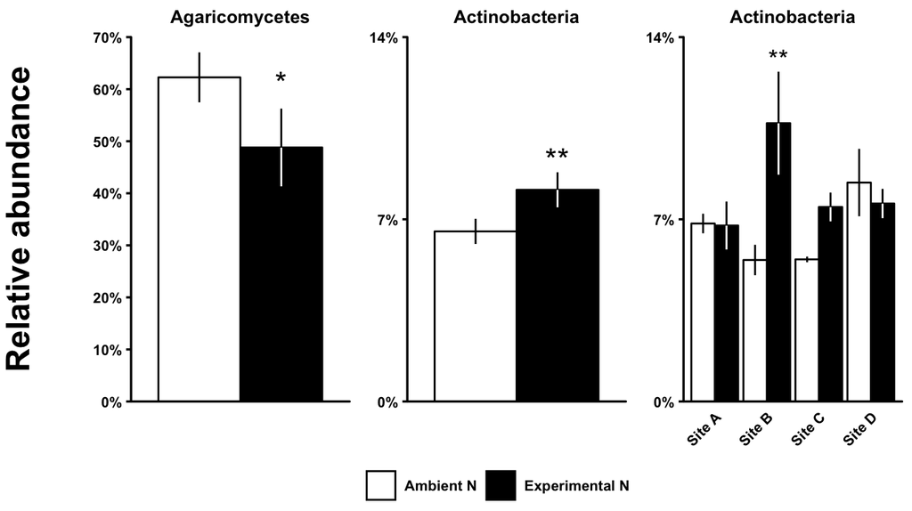

## B. Fungal orders

The following set of analyses determines the effect of experimental N deposition on the relative abundances of select fungal orders.

### 1. Order ANOVA

This code runs a two-way ANOVA to determine the effect of experimental N deposition on select fungal orders. ANOVA tests were only run considered for taxa that responded with a percent change of >20% and a total abundance of >1%

```r
# Format fungal taxonomy and get order counts by group
f.order.tbl <- as_tibble(fread("Gradient.28S.Roots.combined.trim.unique.pick.good.filter.unique.precluster.pick.pick.opti_mcc.0.01.cons.taxonomy", sep = "\t", header = TRUE)) %>%
  # Rename columns
  dplyr::rename(SIZE = Size, TAXONOMY = Taxonomy) %>%
  # Remove SIZE column
  dplyr::select(-SIZE) %>%
  # Separate taxonomic ranks
  tidyr::separate(TAXONOMY, c("ROOT", "KINGDOM", "PHYLUM", "CLASS", "ORDER", "FAMILY", "GENUS"), ";") %>%
  # Convert to long format
  tidyr::gather(TAXONOMIC.RANK, TAXONOMIC.CLASSIFICATION, -OTU) %>%
  # Clean up taxonomy
  dplyr::mutate(CLEAN.TAXONOMIC.CLASSIFICATION = gsub("\\(\\d.*", "", TAXONOMIC.CLASSIFICATION)) %>%
  # Drop old taxonomy
  dplyr::select(-TAXONOMIC.CLASSIFICATION) %>%
  # Merge with OTU counts
  dplyr::inner_join(., f.otu.tbl, by = "OTU") %>%
  # Convert to wide format
  tidyr::spread(TAXONOMIC.RANK, CLEAN.TAXONOMIC.CLASSIFICATION) %>%
  # Group
  dplyr::group_by(GROUP, PHYLUM, CLASS, ORDER) %>%
  # Calculate order counts
  dplyr::summarise(COUNT = sum(COUNT)) %>%
  # Ungroup
  dplyr::ungroup()

# Hellinger transform order abundances
f.order.h.tbl <- f.order.tbl %>%
  # Add order ID column
  tidyr::unite(ORDER.ID, PHYLUM, CLASS, ORDER, sep = ".", remove = FALSE) %>%
  # Replace spaces with underscores
  dplyr::mutate(ORDER.ID = gsub(" ", "_", ORDER.ID)) %>%
  # Add experimental design
  dplyr::inner_join(exp.tbl, ., by = "GROUP") %>%
  # Group by PLOT
  dplyr::group_by(PLOT) %>%
  # Hellinger transform each OTU
  dplyr::mutate(HELLINGER = sqrt(COUNT / sum(COUNT))) %>%
  # Ungroup
  dplyr::ungroup() %>%
  # Calculate total sum
  dplyr::mutate(TOTAL.COUNT = sum(COUNT)) %>%
  # Group
  dplyr::group_by(PHYLUM, CLASS, ORDER) %>%
  # Calculate total percentage
  dplyr::mutate(TOTAL.PERC = (100 * (sum(COUNT) * (1 / TOTAL.COUNT)))) %>%
  # Ungroup
  dplyr::ungroup() %>%
  # Drop low abundance orders
  dplyr::filter(TOTAL.PERC >= 1) %>%
  # Select relevant columns
  dplyr::select(PLOT, SITE, TREATMENT, ORDER.ID, HELLINGER) %>%
  # Convert to wide format
  tidyr::spread(ORDER.ID, HELLINGER)

# Convert to data frame
f.order.h.df <- as.data.frame(f.order.h.tbl)
# Add row names
row.names(f.order.h.df) <- f.order.h.df$PLOT
# ANOVA
f.order.h.aov <- manova(cbind(as.matrix(f.order.h.df[4 : ncol(f.order.h.df)])) ~ SITE * TREATMENT, data = f.order.h.df)
# Get summary
f.order.h.aov.summary <- summary.aov(f.order.h.aov)

# Write function to clean ANOVA summary list names
clean_anova_names <- function(aa) {
  # Get name
  tmp1 <- gsub(" Response ", "", aa)

  # Return results
  return(tmp1)
}

# Fisher's lsd Hypocreales
f.hypo.h.lsd <- LSD.test(aov(cbind(as.matrix(f.order.h.df[8])) ~ SITE * TREATMENT, data = f.order.h.df), c("SITE", "TREATMENT"), alpha = 0.05, p.adj = "none")

# Fisher's lsd Tremellales
f.trem.h.lsd <- LSD.test(aov(cbind(as.matrix(f.order.h.df[17])) ~ SITE * TREATMENT, data = f.order.h.df), c("SITE", "TREATMENT"), alpha = 0.05, p.adj = "none")

# Format ANOVA results
names(f.order.h.aov.summary) <- sapply(names(f.order.h.aov.summary), clean_anova_names)
# Collapse into tibble
f.order.h.aov.summary.tbl <- as_tibble(do.call(rbind, f.order.h.aov.summary), rownames = "ORDER.ID") %>%
  # Rename columns
  dplyr::rename(DF = Df,
                SUM.SQ = "Sum Sq",
                MEAN.SQ = "Mean Sq",
                F.VAL = "F value",
                P.VAL = "Pr(>F)") %>%
  # Split the ID column
  tidyr::separate(ORDER.ID, c("PHYLUM", "CLASS", "ORDER", "COMPARISON"), "\\.") %>%
  # Recreate ORDER ID
  tidyr::unite(ORDER.ID, PHYLUM, CLASS, ORDER, sep = ".") %>%
  # Trim whitespace
  dplyr::mutate(COMPARISON = trimws(COMPARISON)) %>%
  # Select only necessary columns
  dplyr::select(ORDER.ID, COMPARISON, P.VAL) %>%
  # Remove residuals
  dplyr::filter(COMPARISON != "Residuals") %>%
  # Convert to wide format
  tidyr::spread(COMPARISON, P.VAL) %>%
  # Rename columns
  dplyr::rename(SITE.P = SITE,
                SITE.TREATMENT.P = 'SITE:TREATMENT',
                TREATMENT.P = TREATMENT)
```

### 2. Fungal orders percent change

The percent change in the relative abundance of select fungal orders is calculated below.

```r
# Calculate percent change
f.order.perc.change.tbl <- f.order.tbl %>%
  # Add order ID column
  tidyr::unite(ORDER.ID, PHYLUM, CLASS, ORDER, sep = ".", remove = FALSE) %>%
  # Replace spaces with underscores
  dplyr::mutate(ORDER.ID = gsub(" ", "_", ORDER.ID)) %>%
  # Add experimental design
  dplyr::inner_join(exp.tbl, ., by = "GROUP") %>%
  # Group by PLOT
  dplyr::group_by(PLOT) %>%
  # Calculate percentages
  dplyr::mutate(PERC = 100 * (COUNT / sum(COUNT))) %>%
  # Ungroup
  dplyr::ungroup() %>%
  # Calculate total sum
  dplyr::mutate(TOTAL.COUNT = sum(COUNT)) %>%
  # Group
  dplyr::group_by(ORDER.ID) %>%
  # Calculate total percentage
  dplyr::mutate(TOTAL.PERC = (100 * (sum(COUNT) * (1 / TOTAL.COUNT)))) %>%
  # Ungroup
  dplyr::ungroup() %>%
  # Drop low abundance orders
  dplyr::filter(TOTAL.PERC >= 1) %>%
  # Select relevant columns
  dplyr::select(PLOT, SITE, TREATMENT, ORDER.ID, PERC) %>%
  # Group
  dplyr::group_by(ORDER.ID, TREATMENT) %>%
  # Calculate mean and SE
  dplyr::summarise(MEAN.PERC = mean(PERC),
                   SE.PERC = se(PERC)) %>%
  # Ungroup
  dplyr::ungroup() %>%
  # Convert to long format
  tidyr::gather(PARAMETER, PERC, -ORDER.ID, -TREATMENT) %>%
  # Create new parameter column
  tidyr::unite(PARAMETER, TREATMENT, PARAMETER, sep = "_") %>%
  # Convert to wide format
  tidyr::spread(PARAMETER, PERC) %>%
  # Calculate percent change
  dplyr::mutate(PERC.CHANGE = 100 * ((Ndep_MEAN.PERC - Amb_MEAN.PERC) * (1 / Amb_MEAN.PERC))) %>%
  # Select only orders with |% change| >= 20%
  dplyr::filter(abs(PERC.CHANGE) >= 20) %>%
  # Join with ANOVA results
  dplyr::inner_join(., f.order.h.aov.summary.tbl, by = "ORDER.ID") %>%
  # Separate ORDER.ID column
  tidyr::separate(ORDER.ID, c("PHYLUM", "CLASS", "ORDER"), sep = "\\.") %>%
  # Drop unnecessary columns
  dplyr::select(PHYLUM, CLASS, ORDER, PERC.CHANGE, SITE.P, TREATMENT.P, SITE.TREATMENT.P) %>%
  # Sort
  dplyr::arrange(ORDER)

# Calculate abundances as percentages
f.order.perc.tbl <- f.order.tbl %>%
  # Add order ID column
  tidyr::unite(ORDER.ID, PHYLUM, CLASS, ORDER, sep = ".", remove = FALSE) %>%
  # Replace spaces with underscores
  dplyr::mutate(ORDER.ID = gsub(" ", "_", ORDER.ID)) %>%
  # Add experimental design
  dplyr::inner_join(exp.tbl, ., by = "GROUP") %>%
  # Group by PLOT
  dplyr::group_by(PLOT) %>%
  # Calculate percentages
  dplyr::mutate(PERC = 100 * (COUNT / sum(COUNT))) %>%
  # Ungroup
  dplyr::ungroup() %>%
  # Calculate total sum
  dplyr::mutate(TOTAL.COUNT = sum(COUNT)) %>%
  # Group
  dplyr::group_by(PHYLUM, CLASS, ORDER) %>%
  # Calculate total percentage
  dplyr::mutate(TOTAL.PERC = (100 * (sum(COUNT) * (1 / TOTAL.COUNT)))) %>%
  # Ungroup
  dplyr::ungroup() %>%
  # Drop low abundance orders
  dplyr::filter(TOTAL.PERC >= 1) %>%
  # Select relevant columns
  dplyr::select(PLOT, SITE, TREATMENT, ORDER.ID, PERC) %>%
  # Group
  dplyr::group_by(ORDER.ID, TREATMENT) %>%
  # Calculate mean and SE
  dplyr::summarise(MEAN.PERC = mean(PERC),
                   SE.PERC = se(PERC)) %>%
  # Ungroup
  dplyr::ungroup() %>%
  # Convert to long format
  tidyr::gather(PARAMETER, PERC, -ORDER.ID, -TREATMENT) %>%
  # Create new parameter column
  tidyr::unite(PARAMETER, TREATMENT, PARAMETER, sep = "_") %>%
  # Convert to wide format
  tidyr::spread(PARAMETER, PERC) %>%
  # Calculate percent change
  dplyr::mutate(PERC.CHANGE = 100 * ((Ndep_MEAN.PERC - Amb_MEAN.PERC) * (1 / Amb_MEAN.PERC))) %>%
  # Select only orders with |% change| >= 20%
  dplyr::filter(abs(PERC.CHANGE) >= 20) %>%
  # Drop unnecessary columns
  dplyr::select(-PERC.CHANGE) %>%
  # Convert to wide format
  tidyr::gather(PARAMETER, PERC, -ORDER.ID) %>%
  # Separate parameter column
  tidyr::separate(PARAMETER, c("TREATMENT", "PARAMETER"), sep = "\\_") %>%
  # Convert to wide format
  tidyr::spread(PARAMETER, PERC) %>%
  # Join with ANOVA results
  dplyr::inner_join(., f.order.h.aov.summary.tbl, by = "ORDER.ID") %>%
  # Drop non-significant taxa
  dplyr::filter(TREATMENT.P < 0.1) %>%
  # Separate ORDER.ID column
  tidyr::separate(ORDER.ID, c("PHYLUM", "CLASS", "ORDER"), sep = "\\.") %>%
  # Calculate error bar limits
  dplyr::mutate(ERROR.BAR.MAX = MEAN.PERC + SE.PERC,
                ERROR.BAR.MIN = MEAN.PERC - SE.PERC) %>%
  # Add bottom error bar color
  dplyr::mutate(ERROR.BAR.COLOR = ifelse(TREATMENT == "Amb", "black", "white")) %>%
  # Add significance label
  dplyr::mutate(SIG.LABEL = ifelse(TREATMENT == "Ndep" & TREATMENT.P < 0.1 & TREATMENT.P >= 0.05, "*", ""),
                SIG.LABEL = ifelse(TREATMENT == "Ndep" & TREATMENT.P < 0.05, "**", SIG.LABEL))
```

### 3. Fungal supplemental order bar plots

This code creates bar plots for select fungal orders that were used to create **Figure S3**.

```r
# Get percent order table for Tremellales
f.order.perc.trem.tbl <- f.order.tbl %>%
  # Add order ID column
  tidyr::unite(ORDER.ID, PHYLUM, CLASS, ORDER, sep = ".", remove = FALSE) %>%
  # Replace spaces with underscores
  dplyr::mutate(ORDER.ID = gsub(" ", "_", ORDER.ID)) %>%
  # Add experimental design
  dplyr::inner_join(exp.tbl, ., by = "GROUP") %>%
  # Group by GROUP
  dplyr::group_by(GROUP) %>%
  # Calculate percentages
  dplyr::mutate(PERC = 100 * (COUNT / sum(COUNT))) %>%
  # Ungroup
  dplyr::ungroup() %>%
  # Calculate total sum
  dplyr::mutate(TOTAL.COUNT = sum(COUNT)) %>%
  # Group
  dplyr::group_by(PHYLUM, CLASS, ORDER) %>%
  # Calculate total percentage
  dplyr::mutate(TOTAL.PERC = (100 * (sum(COUNT) * (1 / TOTAL.COUNT)))) %>%
  # Ungroup
  dplyr::ungroup() %>%
  # Select Thelephorales
  dplyr::filter(ORDER == "Tremellales") %>%
  # Select relevant columns
  dplyr::select(GROUP, PLOT, SITE, TREATMENT, ORDER.ID, PERC) %>%
  # Group
  dplyr::group_by(ORDER.ID, SITE, TREATMENT) %>%
  # Calculate mean and SE
  dplyr::summarise(MEAN.PERC = mean(PERC),
                   SE.PERC = se(PERC)) %>%
  # Ungroup
  dplyr::ungroup() %>%
  # Separate ORDER.ID column
  tidyr::separate(ORDER.ID, c("PHYLUM", "CLASS", "ORDER"), sep = "\\.") %>%
  # Calculate error bar limits
  dplyr::mutate(ERROR.BAR.MAX = MEAN.PERC + SE.PERC,
                ERROR.BAR.MIN = MEAN.PERC - SE.PERC) %>%
  # Add bottom error bar color
  dplyr::mutate(ERROR.BAR.COLOR = ifelse(TREATMENT == "Amb", "black", "white"))

# Tremallales figure
f.trem.site.fig <- ggplot(f.order.perc.trem.tbl, aes(x = SITE, y = MEAN.PERC, fill = TREATMENT)) +
  # Specify boxplot
  geom_bar(stat = "identity",
           colour = "black",
           position = position_dodge(0.9)) +
  geom_errorbar(aes(ymax = MEAN.PERC, ymin = ERROR.BAR.MIN, colour = ERROR.BAR.COLOR),
                position = position_dodge(0.9),
                width = 0) +
  scale_color_identity() +
  geom_errorbar(aes(ymax = ERROR.BAR.MAX, ymin = MEAN.PERC),
                position = position_dodge(0.9),
                width = 0,
                colour = "black") +
  scale_y_continuous(expand = c(0, 0),
                     limits = c(0, 35),
                     breaks = c(0, 5, 10, 15, 20, 25, 30, 35),
                     labels = c("0%", "5%", "10%", "15%", "20%", "25%", "30%", "35%")) +
  scale_x_discrete(breaks = waiver(),
                   labels = c("Site A", "Site B", "Site C", "Site D")) +
  # Update labels on treatment/time legend
  scale_fill_manual(values = c("white", "black"),
                    labels = c("  Ambient N  ", "  Experimental N")) +
  guides(title = NULL) +
  # Add x axis label
  labs(title = "Tremellales",
       x = NULL,
       # Add y axis label
       y = NULL) +
  # Format plot
  theme(legend.title = element_blank(),
        # Remove panel and legend backgrounds
        panel.grid.major = element_blank(),
        panel.grid.minor = element_blank(),
        panel.background = element_blank(),
        legend.key = element_blank(),
        # Add axis lines
        axis.line.x = element_line(colour = "black", size = 0.6),
        axis.line.y = element_line(colour = "black", size = 0.6),
        # Format text
        plot.title = element_text(colour = "black", size = 10, face = "bold", hjust = 0.5),
        axis.title.y = element_text(colour = "black", size = 14, face = "bold"),
        axis.text.x = element_text(colour = "black", size = 8, face = "bold", angle = 45, hjust = 1),
        axis.ticks.x = element_blank(),
        axis.ticks.y = element_line(colour = "black", size = 0.6),
        axis.text.y = element_text(colour = "black", size = 8, face = "bold"),
        legend.text = element_text(colour = "black", size = 8, face = "bold")) +
annotate("text",
         x = c(0.725, 1.225, 1.725, 2.225, 2.725, 3.225, 3.725, 4.225),
         y = f.order.perc.trem.tbl$ERROR.BAR.MAX + 1,
         label = c("", "", "", "**", "", "*", "", ""),
         size = 5)

# Get percent order table for Hypocreales
f.order.perc.hypo.tbl <- f.order.tbl %>%
  # Add order ID column
  tidyr::unite(ORDER.ID, PHYLUM, CLASS, ORDER, sep = ".", remove = FALSE) %>%
  # Replace spaces with underscores
  dplyr::mutate(ORDER.ID = gsub(" ", "_", ORDER.ID)) %>%
  # Add experimental design
  dplyr::inner_join(exp.tbl, ., by = "GROUP") %>%
  # Group by GROUP
  dplyr::group_by(GROUP) %>%
  # Calculate percentages
  dplyr::mutate(PERC = 100 * (COUNT / sum(COUNT))) %>%
  # Ungroup
  dplyr::ungroup() %>%
  # Calculate total sum
  dplyr::mutate(TOTAL.COUNT = sum(COUNT)) %>%
  # Group
  dplyr::group_by(PHYLUM, CLASS, ORDER) %>%
  # Calculate total percentage
  dplyr::mutate(TOTAL.PERC = (100 * (sum(COUNT) * (1 / TOTAL.COUNT)))) %>%
  # Ungroup
  dplyr::ungroup() %>%
  # Select Thelephorales
  dplyr::filter(ORDER == "Hypocreales") %>%
  # Select relevant columns
  dplyr::select(GROUP, PLOT, SITE, TREATMENT, ORDER.ID, PERC) %>%
  # Group
  dplyr::group_by(ORDER.ID, SITE, TREATMENT) %>%
  # Calculate mean and SE
  dplyr::summarise(MEAN.PERC = mean(PERC),
                   SE.PERC = se(PERC)) %>%
  # Ungroup
  dplyr::ungroup() %>%
  # Separate ORDER.ID column
  tidyr::separate(ORDER.ID, c("PHYLUM", "CLASS", "ORDER"), sep = "\\.") %>%
  # Calculate error bar limits
  dplyr::mutate(ERROR.BAR.MAX = MEAN.PERC + SE.PERC,
                ERROR.BAR.MIN = MEAN.PERC - SE.PERC) %>%
  # Add bottom error bar color
  dplyr::mutate(ERROR.BAR.COLOR = ifelse(TREATMENT == "Amb", "black", "white"))

# Hypocreales figure
f.hypo.site.fig <- ggplot(f.order.perc.hypo.tbl, aes(x = SITE, y = MEAN.PERC, fill = TREATMENT)) +
  # Specify boxplot
  geom_bar(stat = "identity",
           colour = "black",
           position = position_dodge(0.9)) +
  geom_errorbar(aes(ymax = MEAN.PERC, ymin = ERROR.BAR.MIN, colour = ERROR.BAR.COLOR),
                position = position_dodge(0.9),
                width = 0) +
  scale_color_identity() +
  geom_errorbar(aes(ymax = ERROR.BAR.MAX, ymin = MEAN.PERC),
                position = position_dodge(0.9),
                width = 0,
                colour = "black") +
  scale_y_continuous(expand = c(0, 0),
                     limits = c(0, 8),
                     breaks = c(0, 2, 4, 6, 8),
                     labels = c("0%", "2%", "4%", "6%", "8%")) +
  scale_x_discrete(breaks = waiver(),
                   labels = c("Site A", "Site B", "Site C", "Site D")) +
  # Update labels on treatment/time legend
  scale_fill_manual(values = c("white", "black"),
                    labels = c("  Ambient N  ", "  Experimental N")) +
  guides(title = NULL) +
  # Add x axis label
  labs(title = "Hypocreales",
       x = NULL,
       # Add y axis label
       y = NULL) +
  # Format plot
  theme(legend.title = element_blank(),
        # Remove panel and legend backgrounds
        panel.grid.major = element_blank(),
        panel.grid.minor = element_blank(),
        panel.background = element_blank(),
        legend.key = element_blank(),
        # Add axis lines
        axis.line.x = element_line(colour = "black", size = 0.6),
        axis.line.y = element_line(colour = "black", size = 0.6),
        # Format text
        plot.title = element_text(colour = "black", size = 10, face = "bold", hjust = 0.5),
        axis.title.y = element_text(colour = "black", size = 14, face = "bold"),
        axis.text.x = element_text(colour = "black", size = 8, face = "bold", angle = 45, hjust = 1),
        axis.ticks.x = element_blank(),
        axis.ticks.y = element_line(colour = "black", size = 0.6),
        axis.text.y = element_text(colour = "black", size = 8, face = "bold"),
        legend.text = element_text(colour = "black", size = 8, face = "bold")) +
annotate("text",
         x = c(0.725, 1.225, 1.725, 2.225, 2.725, 3.225, 3.725, 4.225),
         y = f.order.perc.hypo.tbl$ERROR.BAR.MAX + 1,
         label = c("", "", "", "", "", "**", "", ""),
         size = 5)
```

### 4. Create fungal order bar plots

The following code creates fungal order bar plots used to construct **Figure 2**.

```r
# Fungi figure
f.order.fig <- ggplot(f.order.perc.tbl, aes(x = ORDER, y = MEAN.PERC, fill = TREATMENT)) +
  # Specify boxplot
  geom_bar(stat = "identity",
           colour = "black",
           position = position_dodge(0.9)) +
  geom_errorbar(aes(ymax = MEAN.PERC, ymin = ERROR.BAR.MIN, colour = ERROR.BAR.COLOR),
                position = position_dodge(0.9),
                width = 0) +
  scale_color_identity() +
  geom_errorbar(aes(ymax = ERROR.BAR.MAX, ymin = MEAN.PERC),
                position = position_dodge(0.9),
                width = 0,
                colour = "black") +
  scale_y_continuous(expand = c(0, 0),
                     limits = c(0, 50),
                     breaks = c(0, 10, 20, 30, 40, 50),
                     labels = c("0%", "10%", "20%", "30%", "40%", "50%")) +
  # Update labels on treatment/time legend
  scale_fill_manual(values = c("white", "black"),
                    labels = c("  Ambient N  ", "  Experimental N")) +
  guides(title = NULL) +
  # Add x axis label
  labs(title = "Fungal orders",
       x = NULL,
       # Add y axis label
       y = NULL) +
  # Format plot
  theme(legend.title = element_blank(),
        # Remove panel and legend backgrounds
        panel.grid.major = element_blank(),
        panel.grid.minor = element_blank(),
        panel.background = element_blank(),
        legend.key = element_blank(),
        # Add axis lines
        axis.line.x = element_line(colour = "black", size = 0.6),
        axis.line.y = element_line(colour = "black", size = 0.6),
        # Format text
        plot.title = element_text(colour = "black", size = 14, face = "bold", hjust = 0.5),
        axis.title.y = element_text(colour = "black", size = 14, face = "bold"),
        axis.text.x = element_text(colour = "black", size = 10, face = "bold", angle = 45, hjust = 1),
        axis.ticks.x = element_blank(),
        axis.ticks.y = element_line(colour = "black", size = 0.6),
        axis.text.y = element_text(colour = "black", size = 10, face = "bold"),
        legend.text = element_text(colour = "black", size = 10, face = "bold")) +
  geom_text(aes(label = SIG.LABEL, y = f.order.perc.tbl$MEAN.PERC + 15),
            stat = "identity",
            size = 6)
```

## C. Bacterial families

The following set of analyses assess the effects of experimental N deposition on the relative abundances of select bacterial families.

### 1. Family ANOVA

The following code determines the effects of experimental N deposition on select bacterial families using two-way ANOVA.

```r
# Format bacterial taxonomy and get family counts by group
b.family.tbl <- as_tibble(fread("Gradient.16S.Roots.combined.trim.unique.good.filter.unique.precluster.pick.pick.opti_mcc.0.03.cons.taxonomy", sep = "\t", header = TRUE)) %>%
  # Rename columns
  dplyr::rename(SIZE = Size, TAXONOMY = Taxonomy) %>%
  # Remove SIZE column
  dplyr::select(-SIZE) %>%
  # Separate taxonomic ranks
  tidyr::separate(TAXONOMY, c("DOMAIN", "PHYLUM", "CLASS", "ORDER", "FAMILY", "GENUS"), ";") %>%
  # Convert to long format
  tidyr::gather(TAXONOMIC.RANK, TAXONOMIC.CLASSIFICATION, -OTU) %>%
  # Clean up taxonomy
  dplyr::mutate(CLEAN.TAXONOMIC.CLASSIFICATION = gsub("\\(\\d.*", "", TAXONOMIC.CLASSIFICATION)) %>%
  # Drop old taxonomy
  dplyr::select(-TAXONOMIC.CLASSIFICATION) %>%
  # Merge with OTU counts
  dplyr::inner_join(., b.otu.tbl, by = "OTU") %>%
  # Convert to wide format
  tidyr::spread(TAXONOMIC.RANK, CLEAN.TAXONOMIC.CLASSIFICATION) %>%
  # Group
  dplyr::group_by(GROUP, PHYLUM, CLASS, ORDER, FAMILY) %>%
  # Calculate order counts
  dplyr::summarise(COUNT = sum(COUNT)) %>%
  # Ungroup
  dplyr::ungroup()

# Get family table
b.family.h.tbl <- b.family.tbl %>%
  # Add family ID column
  tidyr::unite(FAMILY.ID, PHYLUM, CLASS, ORDER, FAMILY, sep = ".", remove = FALSE) %>%
  # Add experimental design
  dplyr::inner_join(exp.tbl, ., by = "GROUP") %>%
  # Group by PLOT
  dplyr::group_by(PLOT) %>%
  # Hellinger transform each OTU
  dplyr::mutate(HELLINGER = sqrt(COUNT / sum(COUNT))) %>%
  # Ungroup
  dplyr::ungroup() %>%
  # Calculate total sum
  dplyr::mutate(TOTAL.COUNT = sum(COUNT)) %>%
  # Group
  dplyr::group_by(PHYLUM, CLASS, ORDER, FAMILY) %>%
  # Calculate total percentage
  dplyr::mutate(TOTAL.PERC = (100 * (sum(COUNT) * (1 / TOTAL.COUNT)))) %>%
  # Ungroup
  dplyr::ungroup() %>%
  # Drop low abundance orders
  dplyr::filter(TOTAL.PERC >= 1) %>%
  # Select relevant columns
  dplyr::select(PLOT, SITE, TREATMENT, FAMILY.ID, HELLINGER) %>%
  # Convert to wide format
  tidyr::spread(FAMILY.ID, HELLINGER)

# Convert to data frame
b.family.h.df <- as.data.frame(b.family.h.tbl)
# Add row names
row.names(b.family.h.df) <- b.family.h.df$GROUP
# ANOVA
b.family.h.aov <- manova(cbind(as.matrix(b.family.h.df[4 : ncol(b.family.h.df)])) ~ SITE * TREATMENT, data = b.family.h.df)
# Get summary
b.family.h.aov.summary <- summary.aov(b.family.h.aov)

# Fisher's lsd Microbacteriaceae
b.micr.h.lsd <- LSD.test(aov(cbind(as.matrix(b.family.h.df[6])) ~ SITE * TREATMENT, data = b.family.h.df), c("SITE", "TREATMENT"), alpha = 0.05, p.adj = "none")

# Format ANOVA results
names(b.family.h.aov.summary) <- sapply(names(b.family.h.aov.summary), clean_anova_names)
# Collapse into tibble
b.family.h.aov.summary.tbl <- as_tibble(do.call(rbind, b.family.h.aov.summary), rownames = "FAMILY.ID") %>%
  # Rename columns
  dplyr::rename(DF = Df,
                SUM.SQ = "Sum Sq",
                MEAN.SQ = "Mean Sq",
                F.VAL = "F value",
                P.VAL = "Pr(>F)") %>%
  # Split the ID column
  tidyr::separate(FAMILY.ID, c("PHYLUM", "CLASS", "ORDER", "FAMILY", "COMPARISON"), "\\.") %>%
  # Recreate FAMILY ID
  tidyr::unite(FAMILY.ID, PHYLUM, CLASS, ORDER, FAMILY, sep = ".") %>%
  # Trim whitespace
  dplyr::mutate(COMPARISON = trimws(COMPARISON)) %>%
  # Select only necessary columns
  dplyr::select(FAMILY.ID, COMPARISON, P.VAL) %>%
  # Remove residuals
  dplyr::filter(COMPARISON != "Residuals") %>%
  # Convert to wide format
  tidyr::spread(COMPARISON, P.VAL) %>%
  # Rename columns
  dplyr::rename(SITE.P = SITE,
                SITE.TREATMENT.P = 'SITE:TREATMENT',
                TREATMENT.P = TREATMENT)
```

### 2. Family percent change

This code calculates the percent change in the relative abundance of select bacterial families in response to experimental N deposition.

```r
# Get percent change family
b.family.perc.change.tbl <- b.family.tbl %>%
  # Add family ID column
  tidyr::unite(FAMILY.ID, PHYLUM, CLASS, ORDER, FAMILY, sep = ".", remove = FALSE) %>%
  # Add experimental design
  dplyr::inner_join(exp.tbl, ., by = "GROUP") %>%
  # Group by PLOT
  dplyr::group_by(PLOT) %>%
  # Calculate percentages
  dplyr::mutate(PERC = 100 * (COUNT / sum(COUNT))) %>%
  # Ungroup
  dplyr::ungroup() %>%
  # Calculate total sum
  dplyr::mutate(TOTAL.COUNT = sum(COUNT)) %>%
  # Group
  dplyr::group_by(PHYLUM, CLASS, ORDER, FAMILY) %>%
  # Calculate total percentage
  dplyr::mutate(TOTAL.PERC = (100 * (sum(COUNT) * (1 / TOTAL.COUNT)))) %>%
  # Ungroup
  dplyr::ungroup() %>%
  # Drop low abundance orders
  dplyr::filter(TOTAL.PERC >= 1) %>%
  # Select relevant columns
  dplyr::select(PLOT, SITE, TREATMENT, FAMILY.ID, PERC) %>%
  # Group
  dplyr::group_by(FAMILY.ID, TREATMENT) %>%
  # Calculate mean and SE
  dplyr::summarise(MEAN.PERC = mean(PERC),
                   SE.PERC = se(PERC)) %>%
  # Ungroup
  dplyr::ungroup() %>%
  # Convert to long format
  tidyr::gather(PARAMETER, PERC, -FAMILY.ID, -TREATMENT) %>%
  # Create new parameter column
  tidyr::unite(PARAMETER, TREATMENT, PARAMETER, sep = "_") %>%
  # Convert to wide format
  tidyr::spread(PARAMETER, PERC) %>%
  # Calculate percent change
  dplyr::mutate(PERC.CHANGE = 100 * ((Ndep_MEAN.PERC - Amb_MEAN.PERC) * (1 / Amb_MEAN.PERC))) %>%
  # Select only orders with |% change| >= 20%
  dplyr::filter(abs(PERC.CHANGE) >= 20) %>%
  # Join with ANOVA results
  dplyr::inner_join(., b.family.h.aov.summary.tbl, by = "FAMILY.ID") %>%
  # Separate FAMILY.ID column
  tidyr::separate(FAMILY.ID, c("PHYLUM", "CLASS", "ORDER", "FAMILY"), sep = "\\.") %>%
  # Update order column
  dplyr::mutate(FAMILY = ifelse(FAMILY == "Saccharimonadales_fa", "Saccharimonadales\n(unclassified)", FAMILY),
                FAMILY = ifelse(FAMILY == "Solibacteraceae_(Subgroup_3)", "Solibacteraceae\n(Subgroup 3)", FAMILY),
                FAMILY = ifelse(FAMILY == "WD260_fa", "WD260\n(unclassified)", FAMILY)) %>%
  # Sort
  dplyr::arrange(FAMILY) %>%
  # Select columns
  dplyr::select(FAMILY, PERC.CHANGE, SITE.P, TREATMENT.P, SITE.TREATMENT.P)
```

### 3. Family bar plot

This code creates the bar plots used to construct **Figure 2**.

```r
# Get percent family
b.family.perc.tbl <- b.family.tbl %>%
  # Add family ID column
  tidyr::unite(FAMILY.ID, PHYLUM, CLASS, ORDER, FAMILY, sep = ".", remove = FALSE) %>%
  # Add experimental design
  dplyr::inner_join(exp.tbl, ., by = "GROUP") %>%
  # Group by PLOT
  dplyr::group_by(PLOT) %>%
  # Calculate percentages
  dplyr::mutate(PERC = 100 * (COUNT / sum(COUNT))) %>%
  # Ungroup
  dplyr::ungroup() %>%
  # Calculate total sum
  dplyr::mutate(TOTAL.COUNT = sum(COUNT)) %>%
  # Group
  dplyr::group_by(PHYLUM, CLASS, ORDER, FAMILY) %>%
  # Calculate total percentage
  dplyr::mutate(TOTAL.PERC = (100 * (sum(COUNT) * (1 / TOTAL.COUNT)))) %>%
  # Ungroup
  dplyr::ungroup() %>%
  # Drop low abundance orders
  dplyr::filter(TOTAL.PERC >= 1) %>%
  # Select relevant columns
  dplyr::select(PLOT, SITE, TREATMENT, FAMILY.ID, PERC) %>%
  # Group
  dplyr::group_by(FAMILY.ID, TREATMENT) %>%
  # Calculate mean and SE
  dplyr::summarise(MEAN.PERC = mean(PERC),
                   SE.PERC = se(PERC)) %>%
  # Ungroup
  dplyr::ungroup() %>%
  # Convert to long format
  tidyr::gather(PARAMETER, PERC, -FAMILY.ID, -TREATMENT) %>%
  # Create new parameter column
  tidyr::unite(PARAMETER, TREATMENT, PARAMETER, sep = "_") %>%
  # Convert to wide format
  tidyr::spread(PARAMETER, PERC) %>%
  # Calculate percent change
  dplyr::mutate(PERC.CHANGE = 100 * ((Ndep_MEAN.PERC - Amb_MEAN.PERC) * (1 / Amb_MEAN.PERC))) %>%
  # Select only orders with |% change| >= 20%
  dplyr::filter(abs(PERC.CHANGE) >= 20) %>%
  # Drop unnecessary columns
  dplyr::select(-PERC.CHANGE) %>%
  # Convert to wide format
  tidyr::gather(PARAMETER, PERC, -FAMILY.ID) %>%
  # Separate parameter column
  tidyr::separate(PARAMETER, c("TREATMENT", "PARAMETER"), sep = "\\_") %>%
  # Convert to wide format
  tidyr::spread(PARAMETER, PERC) %>%
  # Join with ANOVA results
  dplyr::inner_join(., b.family.h.aov.summary.tbl, by = "FAMILY.ID") %>%
  # Drop non-significant taxa
  dplyr::filter(TREATMENT.P < 0.1) %>%
  # Separate FAMILY.ID column
  tidyr::separate(FAMILY.ID, c("PHYLUM", "CLASS", "ORDER", "FAMILY"), sep = "\\.") %>%
  # Update order column
  dplyr::mutate(FAMILY = ifelse(FAMILY == "Saccharimonadales_fa", "Saccharimonadales\n(unclassified)", FAMILY),
                FAMILY = ifelse(FAMILY == "Solibacteraceae_(Subgroup_3)", "Solibacteraceae\n(Subgroup 3)", FAMILY),
                FAMILY = ifelse(FAMILY == "WD260_fa", "WD260\n(unclassified)", FAMILY)) %>%
  # Calculate error bar limits
  dplyr::mutate(ERROR.BAR.MAX = MEAN.PERC + SE.PERC,
                ERROR.BAR.MIN = MEAN.PERC - SE.PERC) %>%
  # Add bottom error bar color
  dplyr::mutate(ERROR.BAR.COLOR = ifelse(TREATMENT == "Amb", "black", "white")) %>%
  # Add significance label
  dplyr::mutate(SIG.LABEL = ifelse(TREATMENT == "Ndep" & TREATMENT.P < 0.1 & TREATMENT.P >= 0.05, "*", ""),
                SIG.LABEL = ifelse(TREATMENT == "Ndep" & TREATMENT.P < 0.05, "**", SIG.LABEL))

# Bacteria figure
b.family.fig <- ggplot(b.family.perc.tbl, aes(x = FAMILY, y = MEAN.PERC, fill = TREATMENT)) +
  # Specify boxplot
  geom_bar(stat = "identity",
           colour = "black",
           position = position_dodge(0.9)) +
  geom_errorbar(aes(ymax = MEAN.PERC, ymin = ERROR.BAR.MIN, colour = ERROR.BAR.COLOR),
                position = position_dodge(0.9),
                width = 0) +
  scale_color_identity() +
  geom_errorbar(aes(ymax = ERROR.BAR.MAX, ymin = MEAN.PERC),
                position = position_dodge(0.9),
                width = 0,
                colour = "black") +
  scale_y_continuous(expand = c(0, 0),
                     limits = c(0, 5),
                     breaks = c(0, 1, 2, 3, 4, 5),
                     labels = c("0%", "1%", "2%", "3%", "4%", "5%")) +
  # Update labels on treatment/time legend
  scale_fill_manual(values = c("white", "black"),
                    labels = c("  Ambient N  ", "  Experimental N")) +
  guides(title = NULL) +
  # Add x axis label
  labs(title = "Bacterial families",
       x = NULL,
       # Add y axis label
       y = NULL) +
  # Format plot
  theme(legend.title = element_blank(),
        # Remove panel and legend backgrounds
        panel.grid.major = element_blank(),
        panel.grid.minor = element_blank(),
        panel.background = element_blank(),
        legend.key = element_blank(),
        # Add axis lines
        axis.line.x = element_line(colour = "black", size = 0.6),
        axis.line.y = element_line(colour = "black", size = 0.6),
        # Format text
        plot.title = element_text(colour = "black", size = 14, face = "bold", hjust = 0.5),
        axis.title.y = element_text(colour = "black", size = 14, face = "bold"),
        axis.text.x = element_text(colour = "black", size = 10, face = "bold", angle = 45, hjust = 1),
        axis.ticks.x = element_blank(),
        axis.ticks.y = element_line(colour = "black", size = 0.6),
        axis.text.y = element_text(colour = "black", size = 10, face = "bold"),
        legend.text = element_text(colour = "black", size = 10, face = "bold")) +
  geom_text(aes(label = SIG.LABEL, y = b.family.perc.tbl$MEAN.PERC + 1),
            stat = "identity",
            size = 6)
```

### 4. Supplemental figure

The following code creates the bar plots used to construct **Figure S3**.

```r
# Get percent order table for Microbacteriaceae
b.family.perc.micr.tbl <- b.family.tbl %>%
  # Add family ID column
  tidyr::unite(FAMILY.ID, PHYLUM, CLASS, ORDER, FAMILY, sep = ".", remove = FALSE) %>%
  # Replace spaces with underscores
  dplyr::mutate(FAMILY.ID = gsub(" ", "_", FAMILY.ID)) %>%
  # Add experimental design
  dplyr::inner_join(exp.tbl, ., by = "GROUP") %>%
  # Group by GROUP
  dplyr::group_by(GROUP) %>%
  # Calculate percentages
  dplyr::mutate(PERC = 100 * (COUNT / sum(COUNT))) %>%
  # Ungroup
  dplyr::ungroup() %>%
  # Calculate total sum
  dplyr::mutate(TOTAL.COUNT = sum(COUNT)) %>%
  # Group
  dplyr::group_by(PHYLUM, CLASS, ORDER, FAMILY) %>%
  # Calculate total percentage
  dplyr::mutate(TOTAL.PERC = (100 * (sum(COUNT) * (1 / TOTAL.COUNT)))) %>%
  # Ungroup
  dplyr::ungroup() %>%
  # Select Microbacteriaceae
  dplyr::filter(FAMILY == "Microbacteriaceae") %>%
  # Select relevant columns
  dplyr::select(GROUP, PLOT, SITE, TREATMENT, FAMILY.ID, PERC) %>%
  # Group
  dplyr::group_by(FAMILY.ID, SITE, TREATMENT) %>%
  # Calculate mean and SE
  dplyr::summarise(MEAN.PERC = mean(PERC),
                   SE.PERC = se(PERC)) %>%
  # Ungroup
  dplyr::ungroup() %>%
  # Separate FAMILY.ID column
  tidyr::separate(FAMILY.ID, c("PHYLUM", "CLASS", "ORDER", "FAMILY"), sep = "\\.") %>%
  # Calculate error bar limits
  dplyr::mutate(ERROR.BAR.MAX = MEAN.PERC + SE.PERC,
                ERROR.BAR.MIN = MEAN.PERC - SE.PERC) %>%
  # Add bottom error bar color
  dplyr::mutate(ERROR.BAR.COLOR = ifelse(TREATMENT == "Amb", "black", "white"))

# Microbacteriaceae figure
b.micr.site.fig <- ggplot(b.family.perc.micr.tbl, aes(x = SITE, y = MEAN.PERC, fill = TREATMENT)) +
  # Specify boxplot
  geom_bar(stat = "identity",
           colour = "black",
           position = position_dodge(0.9)) +
  geom_errorbar(aes(ymax = MEAN.PERC, ymin = ERROR.BAR.MIN, colour = ERROR.BAR.COLOR),
                position = position_dodge(0.9),
                width = 0) +
  scale_color_identity() +
  geom_errorbar(aes(ymax = ERROR.BAR.MAX, ymin = MEAN.PERC),
                position = position_dodge(0.9),
                width = 0,
                colour = "black") +
  scale_y_continuous(expand = c(0, 0),
                     limits = c(0, 4),
                     breaks = c(0, 1, 2, 3, 4),
                     labels = c("0%", "1%", "2%", "3%", "4%")) +
  scale_x_discrete(breaks = waiver(),
                   labels = c("Site A", "Site B", "Site C", "Site D")) +
  # Update labels on treatment/time legend
  scale_fill_manual(values = c("white", "black"),
                    labels = c("  Ambient N  ", "  Experimental N")) +
  guides(title = NULL) +
  # Add x axis label
  labs(title = "Microbacteriaceae",
       x = NULL,
       # Add y axis label
       y = NULL) +
  # Format plot
  theme(legend.title = element_blank(),
        # Remove panel and legend backgrounds
        panel.grid.major = element_blank(),
        panel.grid.minor = element_blank(),
        panel.background = element_blank(),
        legend.key = element_blank(),
        # Add axis lines
        axis.line.x = element_line(colour = "black", size = 0.6),
        axis.line.y = element_line(colour = "black", size = 0.6),
        # Format text
        plot.title = element_text(colour = "black", size = 10, face = "bold", hjust = 0.5),
        axis.title.y = element_text(colour = "black", size = 14, face = "bold"),
        axis.text.x = element_text(colour = "black", size = 8, face = "bold", angle = 45, hjust = 1),
        axis.ticks.x = element_blank(),
        axis.ticks.y = element_line(colour = "black", size = 0.6),
        axis.text.y = element_text(colour = "black", size = 8, face = "bold"),
        legend.text = element_text(colour = "black", size = 8, face = "bold")) +
annotate("text",
         x = c(0.725, 1.225, 1.725, 2.225, 2.725, 3.225, 3.725, 4.225),
         y = b.family.perc.micr.tbl$ERROR.BAR.MAX + 0.4,
         label = c("", "", "", "**", "", "", "", ""),
         size = 5)
```

## D. Create final figures

### 1. Create **Figure 2**

This code constructs **Figure 2**.

```r
# Create figure
relabund.manuscript.barplot <- ggarrange(f.order.fig, b.family.fig, ncol = 1, nrow = 2, common.legend = TRUE, legend = "bottom", align = "hv")

# Add y title
relabund.manuscript.final.barplot <- annotate_figure(relabund.manuscript.barplot,
                                                     left = text_grob("Relative abundance\n",
                                                                      color = "black",
                                                                      rot = 90,
                                                                      size = 16,
                                                                      face = "bold",
                                                                      hjust = 0.17))

# Save image by uncommenting the code below
#ggsave("Figure_2.tiff", relabund.manuscript.final.barplot, device = "tiff", width = 7, height = 7.3, units = "in", dpi = 1200)
#ggsave("Figure_2.png", relabund.manuscript.final.barplot, device = "png", width = 7, height = 7.3, units = "in", dpi = 300)
```

**Figure 2** is displayed below:

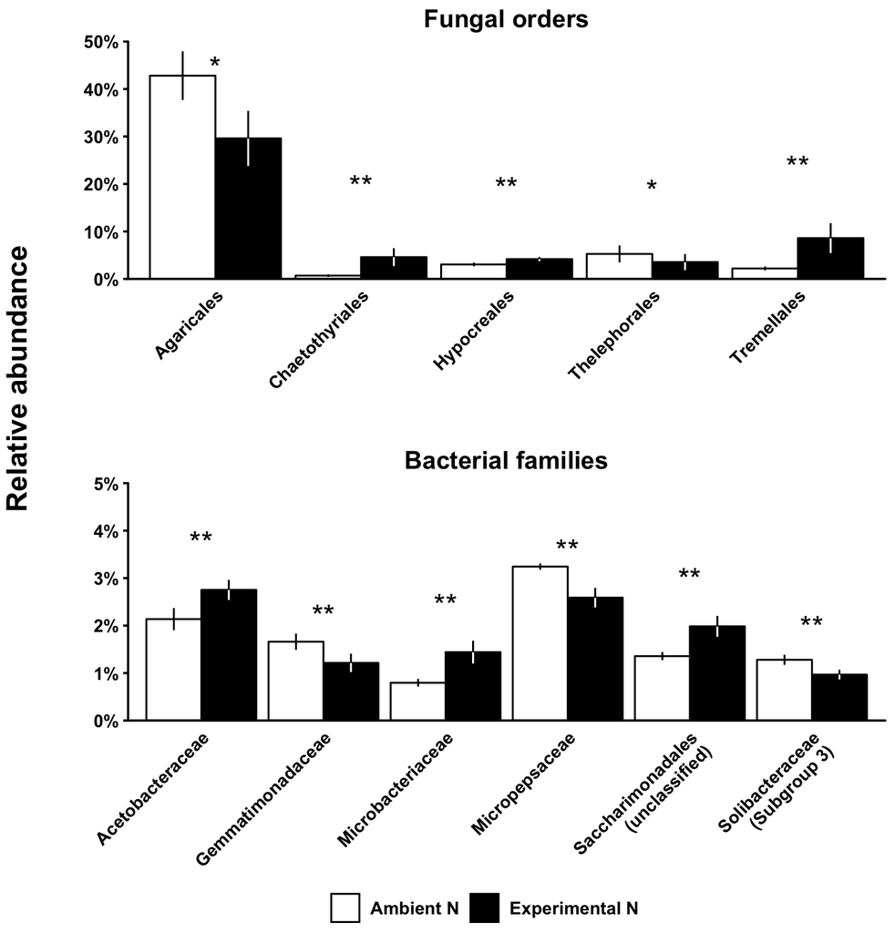

### 2. Construct **Figure S3**

This code was used to construct **Figure S3**.

```r
# Combine plots into one figure
order.family.supplemental.barplot <- ggarrange(f.hypo.site.fig, f.trem.site.fig,
                                               b.micr.site.fig,
                                               ncol = 3, nrow = 1,
                                               common.legend = TRUE,
                                               align = "hv",
                                               legend = "bottom")

# Add y title
order.family.supplemental.final.barplot <- annotate_figure(order.family.supplemental.barplot,
                                                           left = text_grob("Relative abundance\n",
                                                                            color = "black",
                                                                            rot = 90,
                                                                            size = 18,
                                                                            face = "bold",
                                                                            hjust = 0.38))

# Save image by uncommenting the following code
#ggsave("Figure_S3.png", order.family.supplemental.final.barplot, device = "png", width = 178, height = 100, units = "mm", dpi = 300)
```

**Figure S3** is displayed below:

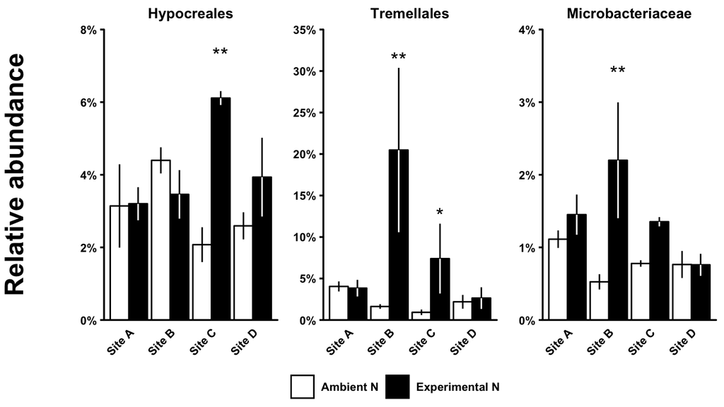

## F. Fungal multivariate statistics

The following set of code runs multivariate analyses for fungal community composition at the genus level.

### 1. PERMANOVA, PERMDISP, db-RDA

The following code runs multivariate analyses to determine the effects of experimental N deposition on the composition of fungal communities at the genus level.

```r
# Get fungal OTU table and format it
f.otu.tbl <- as_tibble(fread("Gradient.28S.Roots.combined.trim.unique.pick.good.filter.unique.precluster.pick.pick.opti_mcc.shared", sep = "\t", header = TRUE)) %>%
  # Remove unnecessary columns
  dplyr::select(-c(label, numOtus)) %>%
  # Rename Group column
  dplyr::rename(GROUP = Group) %>%
  # Convert to long format
  tidyr::gather(OTU, COUNT, -GROUP)

# Format fungal taxonomy and get hellinger-transformed genus counts by group
f.genus.tbl <- as_tibble(fread("Gradient.28S.Roots.combined.trim.unique.pick.good.filter.unique.precluster.pick.pick.opti_mcc.0.01.cons.taxonomy", sep = "\t", header = TRUE)) %>%
  # Rename columns
  dplyr::rename(SIZE = Size, TAXONOMY = Taxonomy) %>%
  # Remove SIZE column
  dplyr::select(-SIZE) %>%
  # Separate taxonomic ranks
  tidyr::separate(TAXONOMY, c("ROOT", "KINGDOM", "PHYLUM", "CLASS", "ORDER", "FAMILY", "GENUS"), ";") %>%
  # Convert to long format
  tidyr::gather(TAXONOMIC.RANK, TAXONOMIC.CLASSIFICATION, -OTU) %>%
  # Clean up taxonomy
  dplyr::mutate(CLEAN.TAXONOMIC.CLASSIFICATION = gsub("\\(\\d.*", "", TAXONOMIC.CLASSIFICATION)) %>%
  # Drop old taxonomy
  dplyr::select(-TAXONOMIC.CLASSIFICATION) %>%
  # Merge with OTU counts
  dplyr::inner_join(., f.otu.tbl, by = "OTU") %>%
  # Convert to wide format
  tidyr::spread(TAXONOMIC.RANK, CLEAN.TAXONOMIC.CLASSIFICATION) %>%
  # Group
  dplyr::group_by(GROUP, PHYLUM, CLASS, ORDER, FAMILY, GENUS) %>%
  # Calculate order counts
  dplyr::summarise(COUNT = sum(COUNT)) %>%
  # Ungroup
  dplyr::ungroup() %>%
  # Convert to wide format
  tidyr::spread(GROUP, COUNT) %>%
  # Add Genus ID column
  dplyr::mutate(GENUS.ID = paste(rep("genus", nrow(.)), c(1 : nrow(.)), sep = "_")) %>%
  # Remove colummns
  dplyr::select(-PHYLUM, -CLASS, -ORDER, -FAMILY, -GENUS) %>%
  # Convert to long format
  tidyr::gather(GROUP, COUNT, -GENUS.ID) %>%
  # Add experimental design
  dplyr::inner_join(exp.tbl, ., by = "GROUP") %>%
  # Group by genus
  dplyr::group_by(GENUS.ID) %>%
  # Add column of OTU totals in overall data set
  dplyr::mutate(TOTAL.COUNT = sum(COUNT)) %>%
  # Ungroup
  dplyr::ungroup() %>%
  # Group by PLOT
  dplyr::group_by(PLOT) %>%
  # Hellinger transform each genus
  dplyr::mutate(HELLINGER = sqrt(COUNT / sum(COUNT))) %>%
  # Ungroup
  dplyr::ungroup() %>%
  # Remove COUNT and TOTAL.COUNT columns
  dplyr::select(-c(COUNT, TOTAL.COUNT)) %>%
  # Convert to wide format
  tidyr::spread(GENUS.ID, HELLINGER) %>%
  # Drop group
  dplyr::select(-GROUP) %>%
  # Sort by plot
  dplyr::arrange(PLOT)

# Convert experimental design to data frame
exp.df <- exp.tbl %>%
  # Filter by time
  dplyr::select(-GROUP) %>%
  # Sort
  dplyr::arrange(PLOT) %>%
  # Convert to data frame
  as.data.frame(.)
# Add row names
row.names(exp.df) <- exp.df$PLOT

# Prepare fungal OTU table for PERMANOVA
f.genus.df <- f.genus.tbl %>%
  # Drop unnecessary columns
  select(-c(SITE, TREATMENT))
# Convert to data frame
f.genus.df <- as.data.frame(f.genus.df)
# Add row names
row.names(f.genus.df) <- f.genus.df$PLOT
# Trim the data frame
f.genus.df <- f.genus.df[2 : ncol(f.genus.df)]

# Calculate Bray-Curtis distance matrix
f.genus.dist <- vegdist(f.genus.df, method = "bray", binary = FALSE)

# Set seed
set.seed(12345)
# Run PERMANOVA for fungal genera
f.genus.pma <- adonis(f.genus.dist ~ SITE * TREATMENT, data = exp.df, permutations = 9999)

# Set seed
set.seed(12345)

# Run SITE dispersion test for fungi
f.genus.site.betadisp <- betadisper(f.genus.dist, exp.df$SITE)
# Run TREATMENT dispersion test for fungi
f.genus.treat.betadisp <- betadisper(f.genus.dist, exp.df$TREATMENT)

# Run SITE permutation test for fungi
f.genus.site.pds <- permutest(f.genus.site.betadisp, pairwise = TRUE, permutations = 9999)
# Run TREATMENT permutation test for fungi
f.genus.treat.pds <- permutest(f.genus.treat.betadisp, pairwise = TRUE, permutations = 9999)

# Set seed
set.seed(12345)
# Run dbRDA
f.genus.dbrda <- capscale(f.genus.df ~ SITE + TREATMENT, data = exp.df, dist = "bray")

# Get summary
f.genus.dbrda.summary <- summary(f.genus.dbrda)
```

Fungal PERMANOVA results are shown below:

```
##
## Call:
## adonis(formula = f.genus.dist ~ SITE * TREATMENT, data = exp.df,      permutations = 9999)
##
## Permutation: free
## Number of permutations: 9999
##
## Terms added sequentially (first to last)
##
##                Df SumsOfSqs  MeanSqs F.Model      R2 Pr(>F)
## SITE            3   0.79859 0.266196  3.2328 0.29388 0.0001 ***
## TREATMENT       1   0.22580 0.225805  2.7423 0.08310 0.0011 **
## SITE:TREATMENT  3   0.37551 0.125171  1.5201 0.13819 0.0256 *
## Residuals      16   1.31746 0.082341         0.48483
## Total          23   2.71737                  1.00000
## ---
## Signif. codes:  0 '***' 0.001 '**' 0.01 '*' 0.05 '.' 0.1 ' ' 1
```

Fungal PERMDISP treatment results are shown below:

```
##
## Permutation test for homogeneity of multivariate dispersions
## Permutation: free
## Number of permutations: 9999
##
## Response: Distances
##           Df   Sum Sq   Mean Sq      F N.Perm Pr(>F)
## Groups     1 0.006314 0.0063136 2.1256   9999 0.1607
## Residuals 22 0.065344 0.0029702
##
## Pairwise comparisons:
## (Observed p-value below diagonal, permuted p-value above diagonal)
##          Amb   Ndep
## Amb          0.1633
## Ndep 0.15898
```

Fungal PERMDISP site results are shown below:

```
##
## Permutation test for homogeneity of multivariate dispersions
## Permutation: free
## Number of permutations: 9999
##
## Response: Distances
##           Df   Sum Sq   Mean Sq      F N.Perm Pr(>F)
## Groups     3 0.010620 0.0035402 1.0162   9999 0.4025
## Residuals 20 0.069674 0.0034837
##
## Pairwise comparisons:
## (Observed p-value below diagonal, permuted p-value above diagonal)
##         A       B       C      D
## A         0.11660 0.37360 0.3565
## B 0.12246         0.66540 0.2509
## C 0.35624 0.65043         0.6577
## D 0.34688 0.24284 0.65086
```

Fungal db-RDA summary is shown below:

```
##
## Call:
## capscale(formula = f.genus.df ~ SITE + TREATMENT, data = exp.df,      distance = "bray")
##
## Partitioning of squared Bray distance:
##               Inertia Proportion
## Total           2.717      1.000
## Constrained     1.024      0.377
## Unconstrained   1.693      0.623
##
## Eigenvalues, and their contribution to the squared Bray distance
##
## Importance of components:
##                         CAP1   CAP2    CAP3   CAP4   MDS1    MDS2   MDS3
## Eigenvalue            0.3535 0.3297 0.18543 0.1557 0.3972 0.18433 0.1625
## Proportion Explained  0.1301 0.1213 0.06824 0.0573 0.1462 0.06784 0.0598
## Cumulative Proportion 0.1301 0.2514 0.31968 0.3770 0.5231 0.59098 0.6508
##                          MDS4    MDS5    MDS6    MDS7    MDS8    MDS9
## Eigenvalue            0.14479 0.10521 0.09257 0.08389 0.07977 0.07358
## Proportion Explained  0.05328 0.03872 0.03407 0.03087 0.02935 0.02708
## Cumulative Proportion 0.70406 0.74278 0.77684 0.80771 0.83707 0.86415
##                         MDS10   MDS11   MDS12  MDS13   MDS14   MDS15
## Eigenvalue            0.07031 0.05618 0.04886 0.0451 0.03774 0.03030
## Proportion Explained  0.02587 0.02068 0.01798 0.0166 0.01389 0.01115
## Cumulative Proportion 0.89002 0.91070 0.92868 0.9453 0.95916 0.97031
##                          MDS16    MDS17    MDS18    MDS19
## Eigenvalue            0.025070 0.022855 0.017841 0.014902
## Proportion Explained  0.009226 0.008411 0.006565 0.005484
## Cumulative Proportion 0.979540 0.987951 0.994516 1.000000
##
## Accumulated constrained eigenvalues
## Importance of components:
##                         CAP1   CAP2   CAP3   CAP4
## Eigenvalue            0.3535 0.3297 0.1854 0.1557
## Proportion Explained  0.3451 0.3219 0.1810 0.1520
## Cumulative Proportion 0.3451 0.6670 0.8480 1.0000
##
## Scaling 2 for species and site scores
## * Species are scaled proportional to eigenvalues
## * Sites are unscaled: weighted dispersion equal on all dimensions
```

[output cut: 786 more lines]

```
## SITEB          0.61658 -0.5008  0.2861 -0.5359    0    0
## SITEC         -0.05426  0.2149 -0.9627 -0.1552    0    0
## SITED         -0.76548 -0.5041  0.2234  0.3316    0    0
## TREATMENTNdep  0.49217 -0.3443 -0.2281  0.7663    0    0
##
##
## Centroids for factor constraints
##
##                   CAP1    CAP2    CAP3    CAP4 MDS1 MDS2
## SITEA          0.20195  0.7854  0.4505  0.3573    0    0
## SITEB          0.61294 -0.4978  0.2844 -0.5327    0    0
## SITEC         -0.05393  0.2136 -0.9570 -0.1542    0    0
## SITED         -0.76096 -0.5011  0.2221  0.3297    0    0
## TREATMENTAmb  -0.28248  0.1976  0.1309 -0.4398    0    0
## TREATMENTNdep  0.28248 -0.1976 -0.1309  0.4398    0    0
```

### 2. Vector fitting

The following code fits vectors of biochemical compound classes in SOM to fungal db-RDA results

```r
# Calculate pyr.gcms.som.source.aov source abundances
pyr.gcms.som.source.tbl <- dplyr::as_tibble(data.table::fread("pyr.gcms.data.txt", sep = "\t", header = TRUE)) %>%
  # Rename columns
  dplyr::rename(COMPOUND_ID = Compound_ID,
                COMPOUND = Compound,
                TYPE = Type,
                SOURCE = Source) %>%
  # Convert to long format
  tidyr::gather(SAMPLE.NAME, PROPORTION, -c(COMPOUND_ID, COMPOUND, TYPE, SOURCE)) %>%
  # Add sample information
  dplyr::inner_join(as_tibble(fread("pyr.gc.sample.info.txt", sep = "\t", header = TRUE)), ., by = "SAMPLE.NAME") %>%
  # Calculate percentages
  dplyr::mutate(PERCENTAGE = 100 * PROPORTION) %>%
  # Fix source names
  dplyr::mutate(SOURCE = ifelse(SOURCE == "Lignin+TMAH", "Lignin", SOURCE),
                SOURCE = ifelse(SOURCE == "Phenol+TMAH", "Phenol", SOURCE),
                SOURCE = ifelse(SOURCE == "Unknown Origin", "Unknown", SOURCE)) %>%
  # Group table
  dplyr::group_by(GROUP, SAMPLE.NAME, PLOT, SITE, TREATMENT, SUBSTRATE, SOURCE) %>%
  # Calculate totals
  dplyr::summarise(PERCENTAGE = sum(PERCENTAGE)) %>%
  # Ungroup
  dplyr::ungroup() %>%
  # Filter
  dplyr::filter(SUBSTRATE == "mineral.soil") %>%
  dplyr::mutate(PERCENTAGE = log2(PERCENTAGE)) %>%
  # Wide format
  tidyr::spread(SOURCE, PERCENTAGE) %>%
  # Select relevant columns
  dplyr::select(-GROUP, -SAMPLE.NAME, -SUBSTRATE) %>%
  # Sort
  dplyr::arrange(PLOT)

# Convert to data frame
pyr.gcms.som.source.df <- as.data.frame(pyr.gcms.som.source.tbl, stringsAsFactors = FALSE)
# Trim
pyr.gcms.som.source.exp.df <- merge(pyr.gcms.som.source.df[c(1, 4:9)], exp.df, by = "PLOT")
# Set seed
set.seed(12345)
# Run envfit
f.genus.som.envfit <- envfit(f.genus.dbrda ~ ., pyr.gcms.som.source.exp.df)

# Format envfit data
f.genus.som.envfit.tbl <- dplyr::as_tibble(rownames_to_column(as.data.frame(f.genus.som.envfit$vectors$arrows))) %>%
  # Add COMPOUND column
  dplyr::rename(COMPOUND = rowname) %>%
  # Trim
  dplyr::filter(COMPOUND == "Lignin" |
                  COMPOUND == "N-Bearing") %>%
  dplyr::mutate(COMPOUND = ifelse(COMPOUND == "Lignin", "bold(paste(Lig, ' **'))", COMPOUND),
                COMPOUND = ifelse(COMPOUND == "N-Bearing", "bold(paste(N-Bear, ' **'))", COMPOUND))
```

Vector fitting results are shown below:

```
##
## ***VECTORS
##
##                    CAP1     CAP2     r2 Pr(>r)
## Aromatic       -0.99478  0.10207 0.0594  0.525
## Lignin          0.81980 -0.57265 0.3860  0.011 *
## Lipid          -0.85290  0.52207 0.1858  0.102
## N-Bearing       0.98695 -0.16103 0.3285  0.022 *
## Phenol          0.97067 -0.24040 0.0501  0.560
## Polysaccharide -0.85523  0.51826 0.0450  0.646
## ---
## Signif. codes:  0 '***' 0.001 '**' 0.01 '*' 0.05 '.' 0.1 ' ' 1
## Permutation: free
## Number of permutations: 999
##
## ***FACTORS:
##
## Centroids:
##                  CAP1    CAP2
## PLOTA1        -0.0024  0.8368
## PLOTA2         0.1581  0.9310
## PLOTA3        -0.1850  0.4897
## PLOTA4         0.5161  0.7944
## PLOTA5         0.4475  1.1065
## PLOTA6         0.2774  0.5539
## PLOTB1         0.2231  0.0777
## PLOTB2         0.1696 -0.4907
## PLOTB3         0.0724 -0.2805
## PLOTB4         1.3410 -1.3894
## PLOTB5         0.6294  0.2512
## PLOTB6         1.2421 -1.1553
## PLOTC1        -0.3681  1.0335
## PLOTC2        -0.7440  0.5536
## PLOTC3        -0.1566  0.4249
## PLOTC4        -0.1874  0.3436
## PLOTC5         0.2911  0.0021
## PLOTC6         0.8415 -1.0762
## PLOTD1        -0.7509 -0.7972
## PLOTD2        -0.7575 -0.0153
## PLOTD3        -1.0483 -0.3922
## PLOTD4        -0.9842 -0.6712
## PLOTD5        -0.8694 -0.3302
## PLOTD6        -0.1554 -0.8008
## SITEA          0.2020  0.7854
## SITEB          0.6129 -0.4978
## SITEC         -0.0539  0.2136
## SITED         -0.7610 -0.5011
## TREATMENTAmb  -0.2825  0.1976
## TREATMENTNdep  0.2825 -0.1976
##
## Goodness of fit:
##               r2 Pr(>r)
## PLOT      1.0000  1.000
## SITE      0.5786  0.001 ***
## TREATMENT 0.1274  0.056 .
## ---
## Signif. codes:  0 '***' 0.001 '**' 0.01 '*' 0.05 '.' 0.1 ' ' 1
## Permutation: free
## Number of permutations: 999
```

### 3. Create db-RDA ordination

This code creates db-RDA ordination figures for **Figure 3**.

```r
# Format points data for dbrda figure
f.genus.dbrda.tbl <- dplyr::as_tibble(rownames_to_column(as.data.frame(f.genus.dbrda$CCA$wa))) %>%
  # Add PLOT column
  dplyr::rename(PLOT = rowname) %>%
  # Add experimental design
  dplyr::inner_join(exp.tbl, ., by = "PLOT") %>%
  # Drop GROUP
  dplyr::select(-GROUP) %>%
  # Sort
  dplyr::arrange(PLOT)  %>%
  # Convert to long format
  tidyr::gather(CAP, LOADING, -c(PLOT, SITE, TREATMENT)) %>%
  # Group by variables
  dplyr::group_by(CAP, SITE, TREATMENT) %>%
  # Calculate mean and se of loadings
  dplyr::summarise(MEAN.LOADING = mean(LOADING), SE.LOADING = se(LOADING)) %>%
  # Ungroup
  dplyr::ungroup() %>%
  # Add error bar limits columns
  dplyr::mutate(EBAR.MAX = MEAN.LOADING + SE.LOADING,
                EBAR.MIN = MEAN.LOADING - SE.LOADING) %>%
  # Convert to long format
  tidyr::gather(LOADING.PARAMETER, VALUE, -c(CAP, SITE, TREATMENT)) %>%
  # Add unique IDs for each CAP
  dplyr::mutate(CAP.KEY = paste(CAP, LOADING.PARAMETER, sep = ".")) %>%
  # Drop unnecessary columns
  dplyr::select(-c(CAP, LOADING.PARAMETER)) %>%
  # Convert to wide format
  tidyr::spread(CAP.KEY, VALUE)

# Format biplot data
f.genus.dbrda.biplot.tbl <- dplyr::as_tibble(rownames_to_column(as.data.frame(f.genus.dbrda$CCA$biplot))) %>%
  # Add VARIABLE column
  dplyr::rename(VARIABLE = rowname) %>%
  # Update label
  dplyr::mutate(VARIABLE = ifelse(VARIABLE == "TREATMENTNdep", "bold(Exp~N)", VARIABLE)) %>%
  # Filter
  dplyr::filter(VARIABLE == "bold(Exp~N)")

# Format fungal taxonomy and get total abundance counts by genus
f.genus.tot.tbl <- as_tibble(fread("Gradient.28S.Roots.combined.trim.unique.pick.good.filter.unique.precluster.pick.pick.opti_mcc.0.01.cons.taxonomy", sep = "\t", header = TRUE)) %>%
  # Rename columns
  dplyr::rename(SIZE = Size, TAXONOMY = Taxonomy) %>%
  # Remove SIZE column
  dplyr::select(-SIZE) %>%
  # Separate taxonomic ranks
  tidyr::separate(TAXONOMY, c("ROOT", "KINGDOM", "PHYLUM", "CLASS", "ORDER", "FAMILY", "GENUS"), ";") %>%
  # Convert to long format
  tidyr::gather(TAXONOMIC.RANK, TAXONOMIC.CLASSIFICATION, -OTU) %>%
  # Clean up taxonomy
  dplyr::mutate(CLEAN.TAXONOMIC.CLASSIFICATION = gsub("\\(\\d.*", "", TAXONOMIC.CLASSIFICATION)) %>%
  # Drop old taxonomy
  dplyr::select(-TAXONOMIC.CLASSIFICATION) %>%
  # Merge with OTU counts
  dplyr::inner_join(., f.otu.tbl, by = "OTU") %>%
  # Convert to wide format
  tidyr::spread(TAXONOMIC.RANK, CLEAN.TAXONOMIC.CLASSIFICATION) %>%
  # Group
  dplyr::group_by(PHYLUM, CLASS, ORDER, FAMILY, GENUS) %>%
  # Calculate order counts
  dplyr::summarise(COUNT = sum(COUNT)) %>%
  # Ungroup
  dplyr::ungroup() %>%
  # Calculate percentage
  dplyr::mutate(PERC = 100 * (COUNT * (1 / sum(COUNT)))) %>%
  # Add Genus ID column
  dplyr::mutate(GENUS.ID = paste(rep("genus", nrow(.)), c(1 : nrow(.)), sep = "_"))

# Format genus scores for dbrda figure
f.genus.dbrda.scr.tbl <- dplyr::as_tibble(rownames_to_column(as.data.frame(f.genus.dbrda$CCA$v))) %>%
  # Add genus ID column
  dplyr::rename(GENUS.ID = rowname) %>%
  # Add genus info
  dplyr::inner_join(f.genus.tot.tbl, ., by = "GENUS.ID") %>%
  # Trim table
  dplyr::filter(PERC >= 1 & GENUS != "unclassified" & GENUS != "uncultured_Thelephoraceae") %>%
  # Add genus label column
  dplyr::mutate(GENUS.LABEL = c("bolditalic(Exo)", "bolditalic(Hyp)", "bolditalic(Cha)", "bolditalic(Ram)",
                                "bolditalic(Kue)", "bolditalic(Hem)", "bolditalic(Myc)", "bolditalic(Chr)",
                                "bolditalic(Umb)")) %>%
  # Add genus function column
  dplyr::mutate(GENUS.FUNCTION = c("Non-Ligninolytic", "Non-Ligninolytic", "Non-Ligninolytic", "Non-Ligninolytic",
                                   "Ligninolytic", "Non-Ligninolytic", "Ligninolytic", "Non-Ligninolytic",
                                   "Non-Ligninolytic"))

# Construct dbrda ordination
f.genus.dbrda.A.fig <- ggplot() +
  # Add horizontal line
  geom_hline(yintercept = 0,
             linetype = "dashed",
             size = 0.5) +
  # Add vertical line
  geom_vline(xintercept = 0,
             linetype = "dashed",
             size = 0.5) +
  # Add dumby point
  geom_point(aes(x = c(-0.5, 1.5),
                 y = c(-0.4, -0.4)),
             alpha = 0,
             inherit.aes = FALSE) +
  # Add species scores
  geom_point(data = f.genus.dbrda.scr.tbl,
             aes(x = CAP1,
                 y = CAP2,
                 size = PERC),
             pch = 16,
             alpha = 0) +
  # Add experimental N vector
  geom_segment(data = f.genus.dbrda.biplot.tbl,
               aes(x = 0, xend = CAP1,
                   y = 0, yend = CAP2),
               size = 1,
               arrow = arrow(length = unit(0.5, "cm")),
               inherit.aes = FALSE,
               colour = "grey50") +
  # Add horizontal error bars
  geom_errorbarh(data = f.genus.dbrda.tbl,
                 aes(xmax = CAP1.EBAR.MAX,
                     xmin = CAP1.EBAR.MIN,
                     y = CAP2.MEAN.LOADING),
                 height = 0,
                 size = 0.75,
                 colour = "black",
                 inherit.aes = FALSE) +
  # Add vertical error bars
  geom_errorbar(data = f.genus.dbrda.tbl,
                aes(x = CAP1.MEAN.LOADING,
                    ymax = CAP2.EBAR.MAX,
                    ymin = CAP2.EBAR.MIN),
                width = 0,
                size = 0.75,
                colour = "black",
                inherit.aes = FALSE) +
  # Add site by treatment centroids
  geom_point(data = f.genus.dbrda.tbl,
             aes(x = CAP1.MEAN.LOADING,
                 y = CAP2.MEAN.LOADING,
                 shape = SITE,
                 fill = TREATMENT),
             size = 3,
             stroke = 1) +
  # Assign shapes by site
  scale_shape_manual(values = c(21:24),
                     labels = c("Site A", "Site B", "Site C", "Site D")) +
  # Update labels on treatment/time legend
  scale_fill_manual(values = c("white", "black"),
                    labels = c("Amb. N", "Exp. N")) +
  # Add title
  labs(title = "A",
       # Add x axis label
       x = "dbRDA Axis 1\n(13.0%)",
       # Add y axis label
       y = "dbRDA Axis 2\n(12.1%)") +
  # Add correct legend shape
   guides(fill = guide_legend(override.aes = list(shape = 21),
                             title = NULL, order = 1),
         shape = guide_legend(title = NULL, order = 2),
         size = FALSE,
         colour = FALSE) +
  # Update y axis ticks and labels
  scale_y_continuous(breaks = c(-0.8, -0.4, 0, 0.4),
                     labels = c("-0.8", "-0.4", "0", "0.4")) +
  # Update x axis ticks and labels
  scale_x_continuous(breaks = c(-1.0, 0, 1.0),
                     labels = c("-1.0", "0", "1.0")) +
  # Modify background
  theme(aspect.ratio = 1,
        panel.border = element_rect(colour = "black", size = 1.5, fill = NA),
        panel.grid.major = element_blank(),
        panel.grid.minor = element_blank(),
        panel.background = element_blank(),
        legend.key = element_blank(),
        plot.margin = margin(0.1, 0.1, 0.1, 0.1, "cm"),
        # Format title and axis text
        plot.title = element_text(colour = "black", size = 20, face = "bold", hjust = 0),
        axis.title.x = element_text(colour = "black", size = 14, face = "bold"),
        axis.title.y = element_text(colour = "black", size = 14, face = "bold"),
        axis.text.x = element_text(colour = "black", size = 10, face = "bold"),
        axis.ticks.x = element_line(colour = "black", size = 1),
        axis.ticks.y = element_line(colour = "black", size = 1),
        axis.text.y = element_text(colour = "black", size = 10, face = "bold"),
        # Format legend text
        legend.text = element_text(colour = "black", size = 8, face = "bold")) +
  geom_text(data = f.genus.dbrda.biplot.tbl,
            aes(x = CAP1, y = CAP2,
                label = VARIABLE),
            hjust = -0.1,
            vjust = 0,
            inherit.aes = FALSE,
            parse = TRUE) +
  # Add SOM vectors
  geom_segment(data = f.genus.som.envfit.tbl,
               aes(x = 0, xend = CAP1,
                   y = 0, yend = CAP2),
               size = 0.5,
               arrow = arrow(length = unit(0.5, "cm")),
               inherit.aes = FALSE,
               alpha = 0) +
  geom_text(data = f.genus.som.envfit.tbl,
            aes(x = CAP1, y = CAP2,
                label = COMPOUND),
            hjust = -0.1,
            vjust = 0,
            inherit.aes = FALSE,
            alpha = 0,
            parse = TRUE)
```

```r
# Construct dbrda ordination
f.genus.dbrda.B.fig <- ggplot() +
  # Add horizontal line
  geom_hline(yintercept = 0,
             linetype = "dashed",
             size = 0.5) +
  # Add vertical line
  geom_vline(xintercept = 0,
             linetype = "dashed",
             size = 0.5) +
  # Add dumby point
  geom_point(aes(x = c(-0.5, 1.5),
                 y = c(-0.4, -0.4)),
             alpha = 0,
             inherit.aes = FALSE) +
  # Add experimental N vector
  geom_segment(data = f.genus.dbrda.biplot.tbl,
               aes(x = 0, xend = CAP1,
                   y = 0, yend = CAP2),
               size = 1,
               arrow = arrow(length = unit(0.5, "cm")),
               inherit.aes = FALSE,
               colour = "grey50") +
  # Add SOM vectors
  geom_segment(data = f.genus.som.envfit.tbl,
               aes(x = 0, xend = CAP1,
                   y = 0, yend = CAP2),
               size = 1,
               arrow = arrow(length = unit(0.5, "cm")),
               inherit.aes = FALSE,
               colour = "grey50") +
  # Add species scores
  geom_point(data = f.genus.dbrda.scr.tbl,
             aes(x = CAP1,
                 y = CAP2,
                 colour = GENUS.FUNCTION,
                 size = PERC),
             pch = 16) +
  # Add labels
  geom_text_repel(data = f.genus.dbrda.scr.tbl,
                  aes(x = CAP1,
                      y = CAP2,
                      label = GENUS.LABEL),
                  hjust = 0,
                  vjust = 0,
                  parse = TRUE) +
  # Add horizontal error bars
  geom_errorbarh(data = f.genus.dbrda.tbl,
                 aes(xmax = CAP1.EBAR.MAX,
                     xmin = CAP1.EBAR.MIN,
                     y = CAP2.MEAN.LOADING),
                 height = 0,
                 size = 0.5,
                 colour = "black",
                 inherit.aes = FALSE,
                 alpha = 0) +
  # Add vertical error bars
  geom_errorbar(data = f.genus.dbrda.tbl,
                aes(x = CAP1.MEAN.LOADING,
                    ymax = CAP2.EBAR.MAX,
                    ymin = CAP2.EBAR.MIN),
                width = 0,
                size = 1,
                colour = "black",
                inherit.aes = FALSE,
                alpha = 0) +
  # Add site by treatment centroids
  geom_point(data = f.genus.dbrda.tbl,
             aes(x = CAP1.MEAN.LOADING,
                 y = CAP2.MEAN.LOADING,
                 shape = SITE,
                 fill = TREATMENT),
             size = 3,
             stroke = 1,
             alpha = 0) +
  # Update color
  scale_colour_manual(values = c("green3", "sienna"),
                      labels = c("Ligninolytic",
                                 "Non-\nLigninolytic")) +
  # Abundance
  scale_size_continuous(breaks = c(5, 10, 15, 20),
                        labels = c("5%", "10%", "15%", "20%")) +
  # Add title
  labs(title = "B",
       # Add x axis label
       x = "db-RDA Axis 1\n(13.0%)",
       # Add y axis label
       y = "db-RDA Axis 2\n(12.1%)") +
  # Add correct legend shape
  guides(fill = FALSE,
         shape = FALSE,
         size = guide_legend(title = NULL, order = 4),
         colour = guide_legend(title = NULL, order = 3)) +
  # Update y axis ticks and labels
  scale_y_continuous(breaks = c(-0.8, -0.4, 0, 0.4),
                     labels = c("-0.8", "-0.4", "0", "0.4")) +
  # Update x axis ticks and labels
  scale_x_continuous(breaks = c(0, 1.0),
                     labels = c("0", "1.0")) +
  # Modify background
  theme(aspect.ratio = 1,
        panel.border = element_rect(colour = "black", size = 1.5, fill = NA),
        panel.grid.major = element_blank(),
        panel.grid.minor = element_blank(),
        panel.background = element_blank(),
        legend.key = element_blank(),
        legend.background = element_blank(),
        plot.margin = margin(0.1, 0.1, 0.1, 0.1, "cm"),
        # Format title and axis text
        plot.title = element_text(colour = "black", size = 20, face = "bold", hjust = 0),
        axis.title.x = element_text(colour = "black", size = 14, face = "bold"),
        axis.title.y = element_text(colour = "black", size = 14, face = "bold"),
        axis.text.x = element_text(colour = "black", size = 10, face = "bold"),
        axis.ticks.x = element_line(colour = "black", size = 1),
        axis.ticks.y = element_line(colour = "black", size = 1),
        axis.text.y = element_text(colour = "black", size = 10, face = "bold"),
        # Format legend text
        legend.text = element_text(colour = "black", size = 8, face = "bold")) +
  # Vector label
  geom_text(data = f.genus.dbrda.biplot.tbl,
            aes(x = CAP1, y = CAP2,
                label = VARIABLE),
            hjust = -0.1,
            vjust = 0,
            inherit.aes = FALSE,
            parse = TRUE) +
  # Add SOM labels
  geom_text(data = f.genus.som.envfit.tbl,
            aes(x = CAP1, y = CAP2,
                label = COMPOUND),
            hjust = -0.1,
            vjust = 0,
            inherit.aes = FALSE,
            parse = TRUE)
```

## G. Bacterial multivariate analyses

The following set of code runs multivariate analyses for bacterial community composition at the family level.

### 1. PERMANOVA, PERMDISP, db-RDA

The following code runs multivariate analyses to determine the effects of experimental N deposition on the composition of bacterial communities at the family level.

```r
# Get bacterial OTU table and format it
b.otu.tbl <- as_tibble(fread("Gradient.16S.Roots.combined.trim.unique.good.filter.unique.precluster.pick.pick.opti_mcc.shared", sep = "\t", header = TRUE)) %>%
  # Remove unnecessary columns
  dplyr::select(-c(label, numOtus)) %>%
  # Rename Group column
  dplyr::rename(GROUP = Group) %>%
  # Convert to long format
  tidyr::gather(OTU, COUNT, -GROUP)

# Format bacterial taxonomy and get Family counts by group
b.family.tbl <- as_tibble(fread("Gradient.16S.Roots.combined.trim.unique.good.filter.unique.precluster.pick.pick.opti_mcc.0.03.cons.taxonomy", sep = "\t", header = TRUE)) %>%
  # Rename columns
  dplyr::rename(SIZE = Size, TAXONOMY = Taxonomy) %>%
  # Remove SIZE column
  dplyr::select(-SIZE) %>%
  # Separate taxonomic ranks
  tidyr::separate(TAXONOMY, c("DOMAIN", "PHYLUM", "CLASS", "ORDER", "FAMILY", "GENUS"), ";") %>%
  # Convert to long format
  tidyr::gather(TAXONOMIC.RANK, TAXONOMIC.CLASSIFICATION, -OTU) %>%
  # Clean up taxonomy
  dplyr::mutate(CLEAN.TAXONOMIC.CLASSIFICATION = gsub("\\(\\d.*", "", TAXONOMIC.CLASSIFICATION)) %>%
  # Drop old taxonomy
  dplyr::select(-TAXONOMIC.CLASSIFICATION) %>%
  # Merge with OTU counts
  dplyr::inner_join(., b.otu.tbl, by = "OTU") %>%
  # Convert to wide format
  tidyr::spread(TAXONOMIC.RANK, CLEAN.TAXONOMIC.CLASSIFICATION) %>%
  # Group
  dplyr::group_by(GROUP, PHYLUM, CLASS, ORDER, FAMILY) %>%
  # Calculate family counts
  dplyr::summarise(COUNT = sum(COUNT)) %>%
  # Ungroup
  dplyr::ungroup() %>%
  # Convert to wide format
  tidyr::spread(GROUP, COUNT) %>%
  # Add family ID column
  dplyr::mutate(FAMILY.ID = paste(rep("family", nrow(.)), c(1 : nrow(.)), sep = "_")) %>%
  # Remove colummns
  dplyr::select(-PHYLUM, -CLASS, -ORDER, -FAMILY) %>%
  # Convert to long format
  tidyr::gather(GROUP, COUNT, -FAMILY.ID) %>%
  # Add experimental design
  dplyr::inner_join(exp.tbl, ., by = "GROUP") %>%
  # Group by family
  dplyr::group_by(FAMILY.ID) %>%
  # Add column of family totals in overall data set
  dplyr::mutate(TOTAL.COUNT = sum(COUNT)) %>%
  # Ungroup
  dplyr::ungroup() %>%
  # Group by PLOT
  dplyr::group_by(PLOT) %>%
  # Hellinger transform each family
  dplyr::mutate(HELLINGER = sqrt(COUNT / sum(COUNT))) %>%
  # Ungroup
  dplyr::ungroup() %>%
  # Remove COUNT and TOTAL.COUNT columns
  dplyr::select(-c(COUNT, TOTAL.COUNT)) %>%
  # Convert to wide format
  tidyr::spread(FAMILY.ID, HELLINGER) %>%
  # Drop group
  dplyr::select(-GROUP) %>%
  # Sort by plot
  dplyr::arrange(PLOT)

# Prepare bacterial family table for PERMANOVA
b.family.df <- b.family.tbl %>%
  # Drop unnecessary columns
  select(-c(SITE, TREATMENT))
# Convert to data frame
b.family.df <- as.data.frame(b.family.df)
# Add row names
row.names(b.family.df) <- b.family.df$PLOT
# Trim the data frame
b.family.df <- b.family.df[2 : ncol(b.family.df)]

# Calculate Bray-Curtis distance matrix
b.family.dist <- vegdist(b.family.df, method = "bray", binary = FALSE)

# Set seed
set.seed(12345)
# Run PERMANOVA for bacterial families
b.family.pma <- adonis(b.family.dist ~ SITE * TREATMENT, data = exp.df, permutations = 9999)

# Set seed
set.seed(12345)

# Run SITE dispersion test for bacteria
b.family.site.betadisp <- betadisper(b.family.dist, exp.df$SITE)
# Run TREATMENT dispersion test for bacteria
b.family.treat.betadisp <- betadisper(b.family.dist, exp.df$TREATMENT)

# Run SITE permutation test for bacteria
b.family.site.pds <- permutest(b.family.site.betadisp, pairwise = TRUE, permutations = 9999)
# Run TREATMENT permutation test for bacteria
b.family.treat.pds <- permutest(b.family.treat.betadisp, pairwise = TRUE, permutations = 9999)

# Set seed
set.seed(12345)

# Run dbRDA
b.family.dbrda <- capscale(b.family.df ~ SITE + TREATMENT, data = exp.df, dist = "bray")

# Get summary
b.family.dbrda.summary <- summary(b.family.dbrda)
```

Bacterial PERMANOVA results are shown below:

```
##
## Call:
## adonis(formula = b.family.dist ~ SITE * TREATMENT, data = exp.df,      permutations = 9999)
##
## Permutation: free
## Number of permutations: 9999
##
## Terms added sequentially (first to last)
##
##                Df SumsOfSqs  MeanSqs F.Model      R2 Pr(>F)
## SITE            3   0.13433 0.044776  2.6364 0.24888 0.0009 ***
## TREATMENT       1   0.04462 0.044619  2.6271 0.08267 0.0137 *
## SITE:TREATMENT  3   0.08904 0.029680  1.7475 0.16497 0.0266 *
## Residuals      16   0.27174 0.016984         0.50348
## Total          23   0.53973                  1.00000
## ---
## Signif. codes:  0 '***' 0.001 '**' 0.01 '*' 0.05 '.' 0.1 ' ' 1
```

Bacterial PERMDISP treatment results are shown below:

```
##
## Permutation test for homogeneity of multivariate dispersions
## Permutation: free
## Number of permutations: 9999
##
## Response: Distances
##           Df   Sum Sq   Mean Sq      F N.Perm Pr(>F)
## Groups     1 0.001346 0.0013465 0.8052   9999 0.3887
## Residuals 22 0.036789 0.0016722
##
## Pairwise comparisons:
## (Observed p-value below diagonal, permuted p-value above diagonal)
##          Amb   Ndep
## Amb          0.3911
## Ndep 0.37926
```

Bacterial PERMDISP site results are shown below:

```
##
## Permutation test for homogeneity of multivariate dispersions
## Permutation: free
## Number of permutations: 9999
##
## Response: Distances
##           Df   Sum Sq   Mean Sq      F N.Perm Pr(>F)
## Groups     3 0.014897 0.0049656 3.0484   9999  0.042 *
## Residuals 20 0.032579 0.0016289
## ---
## Signif. codes:  0 '***' 0.001 '**' 0.01 '*' 0.05 '.' 0.1 ' ' 1
##
## Pairwise comparisons:
## (Observed p-value below diagonal, permuted p-value above diagonal)
##           A         B         C      D
## A           0.0022000 0.2743000 0.0525
## B 0.0069989           0.2861000 0.0248
## C 0.2503258 0.2672453           0.6651
## D 0.0711119 0.0415013 0.6277361
```

Bacterial db-RDA summary is shown below:

```
##
## Call:
## capscale(formula = b.family.df ~ SITE + TREATMENT, data = exp.df,      distance = "bray")
##
## Partitioning of squared Bray distance:
##               Inertia Proportion
## Total          0.5397     1.0000
## Constrained    0.1789     0.3315
## Unconstrained  0.3608     0.6685
##
## Eigenvalues, and their contribution to the squared Bray distance
##
## Importance of components:
##                          CAP1    CAP2    CAP3    CAP4   MDS1    MDS2
## Eigenvalue            0.08684 0.04713 0.02487 0.02010 0.1187 0.08195
## Proportion Explained  0.16090 0.08732 0.04609 0.03724 0.2199 0.15184
## Cumulative Proportion 0.16090 0.24823 0.29431 0.33155 0.5515 0.70331
##                          MDS3    MDS4    MDS5    MDS6    MDS7    MDS8
## Eigenvalue            0.02453 0.01709 0.01506 0.01369 0.01265 0.01146
## Proportion Explained  0.04545 0.03167 0.02790 0.02537 0.02345 0.02124
## Cumulative Proportion 0.74876 0.78043 0.80833 0.83370 0.85715 0.87839
##                          MDS9    MDS10    MDS11    MDS12    MDS13    MDS14
## Eigenvalue            0.01009 0.009498 0.007648 0.007101 0.006949 0.005507
## Proportion Explained  0.01869 0.017597 0.014171 0.013156 0.012875 0.010204
## Cumulative Proportion 0.89708 0.914672 0.928843 0.941999 0.954874 0.965077
##                          MDS15    MDS16    MDS17    MDS18    MDS19
## Eigenvalue            0.004863 0.004753 0.003537 0.003187 0.002508
## Proportion Explained  0.009010 0.008807 0.006553 0.005905 0.004648
## Cumulative Proportion 0.974088 0.982894 0.989447 0.995352 1.000000
##
## Accumulated constrained eigenvalues
## Importance of components:
##                          CAP1    CAP2    CAP3   CAP4
## Eigenvalue            0.08684 0.04713 0.02487 0.0201
## Proportion Explained  0.48531 0.26338 0.13900 0.1123
## Cumulative Proportion 0.48531 0.74868 0.88768 1.0000
##
## Scaling 2 for species and site scores
## * Species are scaled proportional to eigenvalues
## * Sites are unscaled: weighted dispersion equal on all dimensions
```

[output cut: 772 more lines]

```
## SITEB          0.4546  0.4047 -0.7912  0.05965    0    0
## SITEC         -0.2871 -0.1060  0.2709  0.91265    0    0
## SITED          0.6246 -0.1968  0.6505 -0.38471    0    0
## TREATMENTNdep -0.1416  0.9121  0.3813 -0.05176    0    0
##
##
## Centroids for factor constraints
##
##                   CAP1     CAP2     CAP3     CAP4 MDS1 MDS2
## SITEA         -0.52566 -0.06762 -0.08639 -0.38995    0    0
## SITEB          0.30166  0.26857 -0.52509  0.03959    0    0
## SITEC         -0.19052 -0.07036  0.17980  0.60567    0    0
## SITED          0.41452 -0.13058  0.43168 -0.25531    0    0
## TREATMENTAmb   0.05425 -0.34947 -0.14608  0.01983    0    0
## TREATMENTNdep -0.05425  0.34947  0.14608 -0.01983    0    0
```

### 2. Vector fitting

The following code fits vectors of biochemical compound classes in SOM to bacterial db-RDA results

```r
# Set seed
set.seed(12345)

# Run envfit
b.family.som.envfit <- envfit(b.family.dbrda ~ ., pyr.gcms.som.source.exp.df)

# Format envfit data
b.family.som.envfit.tbl <- dplyr::as_tibble(rownames_to_column(as.data.frame(b.family.som.envfit$vectors$arrows))) %>%
  # Add COMPOUND column
  dplyr::rename(COMPOUND = rowname) %>%
  # Trim
  dplyr::filter(COMPOUND == "Lignin" |
                  COMPOUND == "Lipid") %>%
  dplyr::mutate(COMPOUND = ifelse(COMPOUND == "Lignin", "bold(paste(Lig, ' **'))", COMPOUND),
                COMPOUND = ifelse(COMPOUND == "Lipid", "bold(paste(Lip, ' *'))", COMPOUND))
```

Bacterial vector fitting results are as follows:

```
##
## ***VECTORS
##
##                    CAP1     CAP2     r2 Pr(>r)
## Aromatic       -0.96649  0.25669 0.0040  0.963
## Lignin          0.61785  0.78629 0.2886  0.032 *
## Lipid          -0.37553 -0.92681 0.2068  0.072 .
## N-Bearing       0.14589  0.98930 0.1388  0.217
## Phenol         -0.03743  0.99930 0.1293  0.230
## Polysaccharide  0.22680 -0.97394 0.1398  0.212
## ---
## Signif. codes:  0 '***' 0.001 '**' 0.01 '*' 0.05 '.' 0.1 ' ' 1
## Permutation: free
## Number of permutations: 999
##
## ***FACTORS:
##
## Centroids:
##                  CAP1    CAP2
## PLOTA1        -0.4707 -0.4414
## PLOTA2        -0.2719 -0.1124
## PLOTA3        -0.4481 -0.2656
## PLOTA4        -0.6898  0.0053
## PLOTA5        -0.7246  0.0250
## PLOTA6        -0.5489  0.3833
## PLOTB1        -0.0579 -0.3514
## PLOTB2         0.8473 -0.4970
## PLOTB3         0.8862 -0.2531
## PLOTB4         0.3720  1.6825
## PLOTB5        -0.4082  0.0591
## PLOTB6         0.1705  0.9713
## PLOTC1        -0.4838 -0.5256
## PLOTC2         0.1377 -0.7227
## PLOTC3        -0.3770 -0.4116
## PLOTC4        -0.4983 -0.0935
## PLOTC5        -0.1589  0.0995
## PLOTC6         0.2371  1.2318
## PLOTD1         0.4393  0.0773
## PLOTD2        -0.0335 -0.1627
## PLOTD3         0.4834 -0.5273
## PLOTD4         0.3877 -0.2168
## PLOTD5         0.4919 -0.1549
## PLOTD6         0.7183  0.2009
## SITEA         -0.5257 -0.0676
## SITEB          0.3017  0.2686
## SITEC         -0.1905 -0.0704
## SITED          0.4145 -0.1306
## TREATMENTAmb   0.0543 -0.3495
## TREATMENTNdep -0.0543  0.3495
##
## Goodness of fit:
##               r2 Pr(>r)
## PLOT      1.0000  1.000
## SITE      0.3050  0.012 *
## TREATMENT 0.2263  0.001 ***
## ---
## Signif. codes:  0 '***' 0.001 '**' 0.01 '*' 0.05 '.' 0.1 ' ' 1
## Permutation: free
## Number of permutations: 999
```

### 3. Create db-RDA ordinations

This code creates db-RDA ordinations for bacterial composition at the family level that were used to create **Figure 3**.

```r
# Format points data for dbrda figure
b.family.dbrda.tbl <- dplyr::as_tibble(rownames_to_column(as.data.frame(b.family.dbrda$CCA$wa))) %>%
  # Add PLOT column
  dplyr::rename(PLOT = rowname) %>%
  # Add experimental design
  dplyr::inner_join(exp.tbl, ., by = "PLOT") %>%
  # Drop GROUP
  dplyr::select(-GROUP) %>%
  # Sort
  dplyr::arrange(PLOT)  %>%
  # Convert to long format
  tidyr::gather(CAP, LOADING, -c(PLOT, SITE, TREATMENT)) %>%
  # Group by variables
  dplyr::group_by(CAP, SITE, TREATMENT) %>%
  # Calculate mean and se of loadings
  dplyr::summarise(MEAN.LOADING = mean(LOADING), SE.LOADING = se(LOADING)) %>%
  # Ungroup
  dplyr::ungroup() %>%
  # Add error bar limits columns
  dplyr::mutate(EBAR.MAX = MEAN.LOADING + SE.LOADING,
                EBAR.MIN = MEAN.LOADING - SE.LOADING) %>%
  # Convert to long format
  tidyr::gather(LOADING.PARAMETER, VALUE, -c(CAP, SITE, TREATMENT)) %>%
  # Add unique IDs for each CAP
  dplyr::mutate(CAP.KEY = paste(CAP, LOADING.PARAMETER, sep = ".")) %>%
  # Drop unnecessary columns
  dplyr::select(-c(CAP, LOADING.PARAMETER)) %>%
  # Convert to wide format
  tidyr::spread(CAP.KEY, VALUE)

# Format biplot data
b.family.dbrda.biplot.tbl <- dplyr::as_tibble(rownames_to_column(as.data.frame(b.family.dbrda$CCA$biplot))) %>%
  # Add VARIABLE column
  dplyr::rename(VARIABLE = rowname) %>%
  # Update label
  dplyr::mutate(VARIABLE = ifelse(VARIABLE == "TREATMENTNdep", "bold(Exp~N)", VARIABLE)) %>%
  # Filter
  dplyr::filter(VARIABLE == "bold(Exp~N)")

# Format bacterial taxonomy and get total abundance counts by family
b.family.tot.tbl <- as_tibble(fread("Gradient.16S.Roots.combined.trim.unique.good.filter.unique.precluster.pick.pick.opti_mcc.0.03.cons.taxonomy", sep = "\t", header = TRUE)) %>%
  # Rename columns
  dplyr::rename(SIZE = Size, TAXONOMY = Taxonomy) %>%
  # Remove SIZE column
  dplyr::select(-SIZE) %>%
  # Separate taxonomic ranks
  tidyr::separate(TAXONOMY, c("DOMAIN", "PHYLUM", "CLASS", "ORDER", "FAMILY", "GENUS"), ";") %>%
  # Convert to long format
  tidyr::gather(TAXONOMIC.RANK, TAXONOMIC.CLASSIFICATION, -OTU) %>%
  # Clean up taxonomy
  dplyr::mutate(CLEAN.TAXONOMIC.CLASSIFICATION = gsub("\\(\\d.*", "", TAXONOMIC.CLASSIFICATION)) %>%
  # Drop old taxonomy
  dplyr::select(-TAXONOMIC.CLASSIFICATION) %>%
  # Merge with OTU counts
  dplyr::inner_join(., b.otu.tbl, by = "OTU") %>%
  # Convert to wide format
  tidyr::spread(TAXONOMIC.RANK, CLEAN.TAXONOMIC.CLASSIFICATION) %>%
  # Group
  dplyr::group_by(PHYLUM, CLASS, ORDER, FAMILY) %>%
  # Calculate family counts
  dplyr::summarise(COUNT = sum(COUNT)) %>%
  # Ungroup
  dplyr::ungroup() %>%
  # Calculate percentage
  dplyr::mutate(PERC = 100 * (COUNT * (1 / sum(COUNT)))) %>%
  # Add family ID column
  dplyr::mutate(FAMILY.ID = paste(rep("family", nrow(.)), c(1 : nrow(.)), sep = "_"))

# Format family scores for dbrda figure
b.family.dbrda.scr.tbl <- dplyr::as_tibble(rownames_to_column(as.data.frame(b.family.dbrda$CCA$v))) %>%
  # Add family ID column
  dplyr::rename(FAMILY.ID = rowname) %>%
  # Add genus info
  dplyr::inner_join(b.family.tot.tbl, ., by = "FAMILY.ID") %>%
  dplyr::filter(PERC >= 1 & FAMILY != "Unknown_Family" &
                  FAMILY != "Gammaproteobacteria_unclassified" &
                  FAMILY != "Gammaproteobacteria_unclassified" &
                  FAMILY != "WD260_fa" &
                  FAMILY != "Saccharimonadales_fa" &
                  FAMILY != "Caulobacteraceae_unclassified") %>%
  # Add family label column
  dplyr::mutate(FAMILY.LABEL = c("bold(Aci)", "bold(Sol)", "bold(Mib)", "bold('Chi')", "bold(Spb)",
                                 "bold(Gem)", "bold(Ace)",
                                 "bold(Cau)", "bold(Mip)", "bold(Xan)", "bold(Spg)", "bold(Bur)", "bold('Rho')")) %>%
  # Add family function column
  dplyr::mutate(FAMILY.FUNCTION = c("Non-Ligninolytic", "Ligninolytic", "Ligninolytic",
                                    "Non-Ligninolytic", "Ligninolytic", "Non-Ligninolytic",
                                    "Non-Ligninolytic", "Ligninolytic", "Non-Ligninolytic",
                                    "Non-Ligninolytic", "Ligninolytic", "Ligninolytic",
                                    "Ligninolytic"))

# Construct dbrda ordination
b.family.dbrda.C.fig <- ggplot() +
  # Add horizontal line
  geom_hline(yintercept = 0,
             linetype = "dashed",
             size = 0.5) +
  # Add vertical line
  geom_vline(xintercept = 0,
             linetype = "dashed",
             size = 0.5) +
  # Add dumby point
  geom_point(aes(x = c(-0.5, 0.6),
                 y = c(-1, 1)),
             alpha = 0,
             inherit.aes = FALSE) +
  # Add SOM vectors
  geom_segment(data = b.family.som.envfit.tbl,
               aes(x = 0, xend = CAP1,
                   y = 0, yend = CAP2),
               size = 1,
               arrow = arrow(length = unit(0.5, "cm")),
               inherit.aes = FALSE,
               alpha = 0) +
  # Add experimental N vector
  geom_segment(data = b.family.dbrda.biplot.tbl,
               aes(x = 0, xend = CAP1,
                   y = 0, yend = CAP2),
               size = 1,
               arrow = arrow(length = unit(0.5, "cm")),
               inherit.aes = FALSE,
               colour = "grey50") +
  # Add species scores
  geom_point(data = b.family.dbrda.scr.tbl,
             aes(x = CAP1,
                 y = CAP2,
                 size = PERC),
             pch = 16,
             alpha = 0) +
  # Add horizontal error bars
  geom_errorbarh(data = b.family.dbrda.tbl,
                 aes(xmax = CAP1.EBAR.MAX,
                     xmin = CAP1.EBAR.MIN,
                     y = CAP2.MEAN.LOADING),
                 height = 0,
                 size = 0.75,
                 colour = "black",
                 inherit.aes = FALSE) +
  # Add vertical error bars
  geom_errorbar(data = b.family.dbrda.tbl,
                aes(x = CAP1.MEAN.LOADING,
                    ymax = CAP2.EBAR.MAX,
                    ymin = CAP2.EBAR.MIN),
                width = 0,
                size = 0.75,
                colour = "black",
                inherit.aes = FALSE) +
  # Add site by treatment centroids
  geom_point(data = b.family.dbrda.tbl,
             aes(x = CAP1.MEAN.LOADING,
                 y = CAP2.MEAN.LOADING,
                 shape = SITE,
                 fill = TREATMENT),
             size = 3,
             stroke = 1) +
  # Assign shapes by site
  scale_shape_manual(values = c(21:24),
                     labels = c("A", "B", "C", "D")) +
  # Update labels on treatment/time legend
  scale_fill_manual(values = c("white", "black"),
                    labels = c("Amb.", "Exp.")) +
  # Add title
  labs(title = "C",
       # Add x axis label
       x = "db-RDA Axis 1\n(16.1%)",
       # Add y axis label
       y = "db-RDA Axis 2\n(8.7%)") +
  # Add correct legend shape
   guides(fill = guide_legend(override.aes = list(shape = 21),
                             title = NULL, order = 1),
         shape = guide_legend(title = NULL, order = 2),
         size = FALSE,
         colour = FALSE) +
  # Update y axis ticks and labels
  scale_y_continuous(breaks = c(-1, -0.5, 0, 0.5, 1.0),
                     labels = c("-1.0", "-0.5", "0", "0.5", "1.0")) +
  # Update x axis ticks and labels
  scale_x_continuous(breaks = c(-0.4, 0, 0.4),
                     labels = c("-0.4", "0", "0.4")) +
  # Modify background
  theme(aspect.ratio = 1,
        panel.border = element_rect(colour = "black", size = 1.5, fill = NA),
        panel.grid.major = element_blank(),
        panel.grid.minor = element_blank(),
        panel.background = element_blank(),
        legend.key = element_blank(),
        plot.margin = margin(0.1, 0.1, 0.1, 0.1, "cm"),
        # Format title and axis text
        plot.title = element_text(colour = "black", size = 20, face = "bold", hjust = 0),
        axis.title.x = element_text(colour = "black", size = 14, face = "bold"),
        axis.title.y = element_text(colour = "black", size = 14, face = "bold"),
        axis.text.x = element_text(colour = "black", size = 10, face = "bold"),
        axis.ticks.x = element_line(colour = "black", size = 1),
        axis.ticks.y = element_line(colour = "black", size = 1),
        axis.text.y = element_text(colour = "black", size = 10, face = "bold"),
        # Format legend text
        legend.text = element_text(colour = "black", size = 8, face = "bold")) +
  # Add experimental N vector
  geom_text(data = b.family.dbrda.biplot.tbl,
            aes(x = CAP1, y = CAP2,
                label = VARIABLE),
            hjust = -0.1,
            vjust = 0,
            inherit.aes = FALSE,
            parse = TRUE) +
  geom_text(data = b.family.som.envfit.tbl,
            aes(x = CAP1, y = CAP2,
                label = COMPOUND),
            hjust = -0.1,
            vjust = 0,
            inherit.aes = FALSE,
            alpha = 0) +
  # Add SOM vectors
  geom_segment(data = b.family.som.envfit.tbl,
               aes(x = 0, xend = CAP1,
                   y = 0, yend = CAP2),
               size = 0.5,
               arrow = arrow(length = unit(0.5, "cm")),
               inherit.aes = FALSE,
               alpha = 0) +
  geom_text(data = b.family.som.envfit.tbl,
            aes(x = CAP1, y = CAP2,
                label = COMPOUND),
            hjust = 1.1,
            vjust = 0,
            inherit.aes = FALSE,
            alpha = 0,
            parse = TRUE)
```

```r
# Construct dbrda ordination
b.family.dbrda.D.fig <- ggplot() +
  # Add horizontal line
  geom_hline(yintercept = 0,
             linetype = "dashed",
             size = 0.5) +
  # Add vertical line
  geom_vline(xintercept = 0,
             linetype = "dashed",
             size = 0.5) +
   # Add SOM vectors
  geom_segment(data = b.family.som.envfit.tbl,
               aes(x = 0, xend = CAP1,
                   y = 0, yend = CAP2),
               size = 1,
               arrow = arrow(length = unit(0.5, "cm")),
               inherit.aes = FALSE,
               colour = "grey50") +
  # Add experimental N vector
  geom_segment(data = b.family.dbrda.biplot.tbl,
               aes(x = 0, xend = CAP1,
                   y = 0, yend = CAP2),
               size = 1,
               arrow = arrow(length = unit(0.5, "cm")),
               inherit.aes = FALSE,
               colour = "grey50") +
  # Add dumby points
  geom_point(aes(x = c(-0.5, 0.6),
                 y = c(-1, 1)),
             alpha = 0,
             inherit.aes = FALSE) +
  # Add species scores
  geom_point(data = b.family.dbrda.scr.tbl,
             aes(x = CAP1,
                 y = CAP2,
                 colour = FAMILY.FUNCTION,
                 size = PERC),
             pch = 16) +
  # Add labels
  geom_text_repel(data = b.family.dbrda.scr.tbl,
                  aes(x = CAP1,
                      y = CAP2,
                      label = FAMILY.LABEL),
                  hjust = 0,
                  vjust = 0,
                  parse = TRUE,
                  nudge_x = -0.12) +
  # Add horizontal error bars
  geom_errorbarh(data = b.family.dbrda.tbl,
                 aes(xmax = CAP1.EBAR.MAX,
                     xmin = CAP1.EBAR.MIN,
                     y = CAP2.MEAN.LOADING),
                 height = 0,
                 size = 0.75,
                 colour = "black",
                 inherit.aes = FALSE,
                 alpha = 0) +
  # Add vertical error bars
  geom_errorbar(data = b.family.dbrda.tbl,
                aes(x = CAP1.MEAN.LOADING,
                    ymax = CAP2.EBAR.MAX,
                    ymin = CAP2.EBAR.MIN),
                width = 0,
                size = 0.75,
                colour = "black",
                inherit.aes = FALSE,
                alpha = 0) +
  # Add site by treatment centroids
  geom_point(data = b.family.dbrda.tbl,
             aes(x = CAP1.MEAN.LOADING,
                 y = CAP2.MEAN.LOADING,
                 shape = SITE,
                 fill = TREATMENT),
             size = 3,
             stroke = 1,
             alpha = 0) +
  # Update color
  scale_colour_manual(values = c( "green3", "sienna"),
                      labels = c("Ligninolytic",
                                 "Non-\nLigninolytic")) +
  # Abundance
  scale_size_continuous(breaks = c(5, 10, 15),
                        labels = c("5%", "10%", "15%")) +
  # Add title
  labs(title = "D",
       # Add x axis label
       x = "db-RDA Axis 1\n(16.1%)",
       # Add y axis label
       y = "db-RDA Axis 2\n(8.7%)") +
  # Add correct legend shape
  guides(fill = FALSE,
         shape = FALSE,
         size = guide_legend(title = NULL, order = 4),
         colour = guide_legend(title = NULL, order = 3)) +
  # Update y axis ticks and labels
  scale_y_continuous(breaks = c(-1, -0.5, 0, 0.5, 1.0),
                     labels = c("-1.0", "-0.5", "0", "0.5", "1.0")) +
  # Update x axis ticks and labels
  scale_x_continuous(breaks = c(-0.4, 0, 0.4),
                     labels = c("-0.4", "0", "0.4")) +
  # Modify background
  theme(aspect.ratio = 1,
        panel.border = element_rect(colour = "black", size = 1.5, fill = NA),
        panel.grid.major = element_blank(),
        panel.grid.minor = element_blank(),
        panel.background = element_blank(),
        legend.key = element_blank(),
        plot.margin = margin(0.1, 0.1, 0.1, 0.1, "cm"),
        # Format title and axis text
        plot.title = element_text(colour = "black", size = 20, face = "bold", hjust = 0),
        axis.title.x = element_text(colour = "black", size = 14, face = "bold"),
        axis.title.y = element_text(colour = "black", size = 14, face = "bold"),
        axis.text.x = element_text(colour = "black", size = 10, face = "bold"),
        axis.ticks.x = element_line(colour = "black", size = 1),
        axis.ticks.y = element_line(colour = "black", size = 1),
        axis.text.y = element_text(colour = "black", size = 10, face = "bold"),
        # Format legend text
        legend.text = element_text(colour = "black", size = 8, face = "bold")) +
  geom_text(data = b.family.dbrda.biplot.tbl,
            aes(x = CAP1, y = CAP2,
                label = VARIABLE),
            hjust = -0.1,
            vjust = 0,
            inherit.aes = FALSE,
            parse = TRUE) +
  geom_text(data = b.family.som.envfit.tbl,
            aes(x = CAP1, y = CAP2,
                label = COMPOUND),
            hjust = 1.1,
            vjust = 0,
            inherit.aes = FALSE,
            parse = TRUE)
```

## H. Create **Figure 3**

```r
# Create dbRDA figure
manuscript.dbrda.fig <- ggarrange(f.genus.dbrda.A.fig, f.genus.dbrda.B.fig,
                                  b.family.dbrda.C.fig, b.family.dbrda.D.fig,
                                  ncol = 2, nrow = 2,
                                  common.legend = FALSE,
                                  align = "v")

# Save figure by uncommenting the following code
ggsave("Figure_3.tiff", manuscript.dbrda.fig, device = "tiff", width = 10.25, height = 10.25, units = "in", dpi = 1200)
ggsave("Figure_3.png", manuscript.dbrda.fig, device = "png", width = 10.25, height = 10.25, units = "in", dpi = 300)
```

**Figure 3** is shown below:

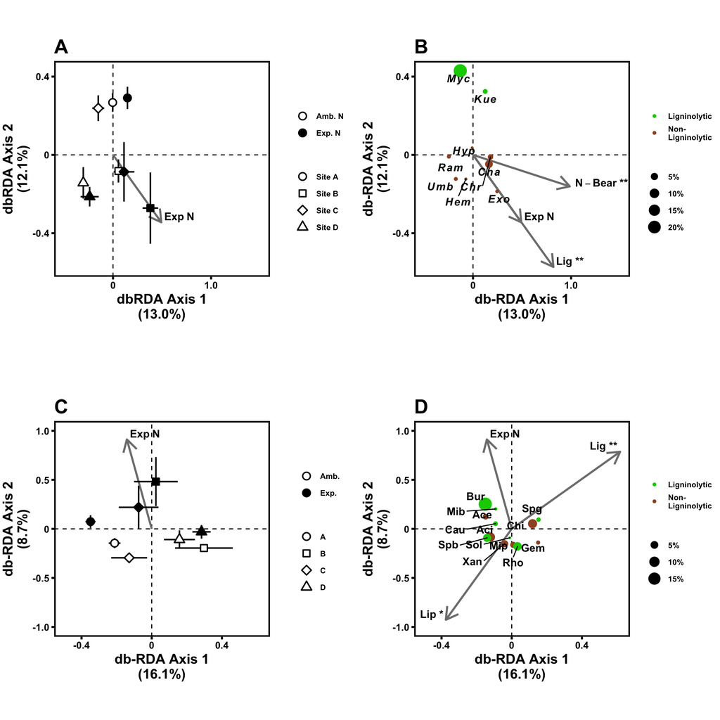